# Forecasting Princples and Practice 2 (5-7)

Koji Mizumura

August 28, 2018(Beg) - October 12(End)

This document is html_notebook output (not html_document).

# 1 Resources

[Forecasting: princples and practice](https://otexts.org/fpp2/)  
[Slides](https://robjhyndman.com/seminars/uwa2017/)  
[Github](https://github.com/nealxun/ForecastingPrinciplePractices)

From the Github, we can install the package `fpp2`.

```r
install.packages("fpp2",dependencies = TRUE
```

# 2 Time series regression models

In this chapter, we discuss regression models. The basic concept is that we forecast the time series of interest $y$ assuming that it has a linear relationship with other time series $x$.

For example, we might wish to forecast monthly sales $y$ using total advertising spend $x$ as a predictor. OR we might forecast daily electricity demand $y$ using temparature $x_1$ and the day of week $x_2$ as predictors.

The **forecast variable $y$** is sometimes called the regressor, dependent or explained variables. The predictor variables$x$ are sometimes also called the regressors, independent or explanatory variables. In this book we will always refer to them as the “forecast” variable and “predictor” variables.

## 2.1 The linear model

### 2.1.1 Simple linear regression

In this simplest case, the regression model allows for a linear relationship between the forecast variable $y$ and a single predictor variable $x$:
$$y_t=\beta_0+ \beta_1x_t+\epsilon_t$$

An rtificial example of data from such a model is shown in Figure 5.1. The coefficients $\beta_0$ and $\beta_1$ denote the intercept and the slope of the line respectively. The intercept $\beta_0$ represents the predicted value of $y$ when $x=0$. The slope $\beta_1$ represents the average predicted change in $y$ resulting from a one unit increase in $x$.

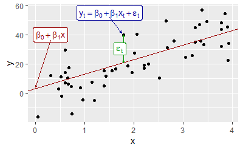

```r
set.seed(2)
x <- runif(50, 0, 4)
df <- data.frame(x=x,
                 y=3 + 10*x + rnorm(50, 0, 10))
ggplot(df, aes(x, y)) +
  geom_point() +
  geom_abline(slope=10, intercept=3,
              col="#990000", size=0.3) +
  geom_label(x=.3, y=40, parse=TRUE, col="#990000",
             label=" beta[0] + beta[1] * x") +
  geom_segment(x=.3, y=36, xend=0, yend=4,
        arrow=arrow(length = unit(0.02, "npc")),
          size=0.2, col='#990000') +
  geom_label(x=1.5, y=55, parse=TRUE, col="#000099",
           label="y[t] == beta[0] + beta[1] * x[t] + epsilon[t]") +
  geom_segment(x=1.5, y=52, xend=df$x[19]-0.03, yend=df$y[19]+1.5,
               arrow=arrow(length = unit(0.02, "npc")),
                 size=0.2, col='#000099') +
  geom_segment(x=df$x[19], y=df$y[19],
               xend=df$x[19], yend=3+10*df$x[19],
               col="#009900", size=0.2,
               arrow=arrow(length=unit(0.02,"npc"), ends="both")) +
  geom_label(x=df$x[19]-0.07,
             y=(df$y[19]+ 3+10*df$x[19])/2,
             col="#009900", label="epsilon[t]",
             parse=TRUE)
```

Notice that the observations do not lie on the straight line but are scattered around it. We can think of each observation $y_t$ consisting of the systematic or explained part of the model, $\beta_0+\beta_1x_t$, and the random “error”, $\varepsilon_t$. The “error” term does not imply a mistake, but a deviation from the underlying straight line model. It captures anything that may affect $y_t$ other than $x_t$.

#### 2.1.1.1 Example: US consumption expenditure

[output not shown]

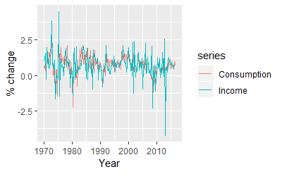

```r
autoplot(uschange[,c("Consumption","Income")]) +
  ylab("% change") + xlab("Year")
```

A scatter plot of consumption against income is shown in Figure @ref(fig:ConsInc2) along with the estimated regression line
$$\hat{y}_t=0.55 + 0.28x_t.$$

(We put a “hat” above $y$ to indicate that this is the value of $y$ predicted by the model.)

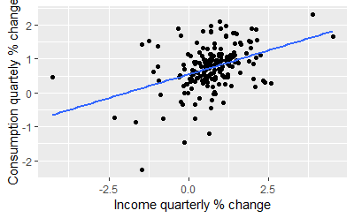

```r
uschange %>%
  as.data.frame() %>%
  ggplot(aes(x=Income,y=Consumption))+
  ylab("Consumption quartely % change")+
  xlab("Income quarterly % change")+
  geom_point()+
  geom_smooth(method="lm",se=FALSE)
```

This equation is estimated in R using the `tslm` function:

```r
tslm(Consumption~Income,data=uschange)
```

```
Call:
tslm(formula = Consumption ~ Income, data = uschange)

Coefficients:
(Intercept)       Income
     0.5451       0.2806
```

We will discuss how `tslm()` computes the coefficients in Section @ref(Regr-LSprinciple).

The fitted line has a positive slope, reflecting the positive relationship between income and consumption. The slope coefficient shows that a one unit increase in $x$ (a 1% increase in personal disposable income) results on average in 0.28 units increase in $y$ (an average 0.28% increase in personal consumption expenditure). Alternatively the estimated equation shows that a value of 1 for $x$ (the percentage increase in personal disposable income) will result in a forecast value of $0.55 + 0.28 \times 1 = 0.83$ for $y$ (the percentage increase in personal consumption expenditure).

The interpretation of the intercept requires that a value of $x=0$ makes sense. In this case when $x=0$ (i.e., when there is no change in personal disposable income since the last quarter) the predicted value of $y$ is 0.55 (i.e., an average increase in personal consumption expenditure of 0.55%). Even when $x=0$ does not make sense, the intercept is an important part of the model. Without it, the slope coefficient can be distorted unnecessarily. The intercept should always be included unless the requirement is to force the regression line “through the origin”. In what follows we assume that an intercept is always included in the model.

### 2.1.2 Multiple linear regression

When there are two or more predictor variables, the model is called a “multiple regression model”. The general form of a multiple regression model is

$$\begin{equation}
y_t = \beta_{0} + \beta_{1} x_{1,t} + \beta_{2} x_{2,t} + \cdots + \beta_{k} x_{k,t} + \varepsilon_t,
\end{equation}$$

where $y$ is the variable to be forecast and $x_{1},\dots,x_{k}$ are the $k$ predictor variables. Each of the predictor variables must be numerical. The coefficients $\beta_{1},\dots,\beta_{k}$ measure the effect of each predictor after taking account of the effect of all other predictors in the model. Thus, the coefficients measure the *marginal effects* of the predictor variables.

#### 2.1.2.1 Example: US consumption expenditure

Figure @ref(fig:MultiPredictors) shows additional predictors that may be useful for forecasting US consumption expenditure. These are quarterly percentage changes in industrial production and personal savings, and quarterly changes in the unemployment rate (as this is already a percentage). Building a multiple linear regression model can potentially generate more accurate forecasts as we expect consumption expenditure to not only depend on personal income but on other predictors as well.

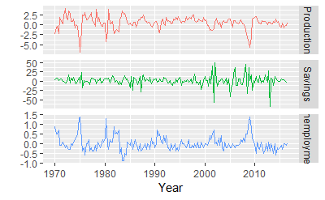

The first column of Figure @ref(fig:ScatterMatrix) below shows the relationships between consumption and each of the predictors. The scatterplots show positive relationships with income and industrial production, and negative relationships with savings and unemployment. The strength of these relationships are shown by the correlation coefficients across the first row. The remaining scatterplots and correlation coefficients show the relationships between the predictors

```r
head(uschange)
```

```
        Consumption     Income Production   Savings
1970 Q1   0.6159862  0.9722610 -2.4527003 4.8103115
1970 Q2   0.4603757  1.1690847 -0.5515251 7.2879923
1970 Q3   0.8767914  1.5532705 -0.3587079 7.2890131
1970 Q4  -0.2742451 -0.2552724 -2.1854549 0.9852296
1971 Q1   1.8973708  1.9871536  1.9097341 3.6577706
1971 Q2   0.9119929  1.4473342  0.9015358 6.0513418
        Unemployment
1970 Q1          0.9
1970 Q2          0.5
1970 Q3          0.5
1970 Q4          0.7
1971 Q1         -0.1
1971 Q2         -0.1
```

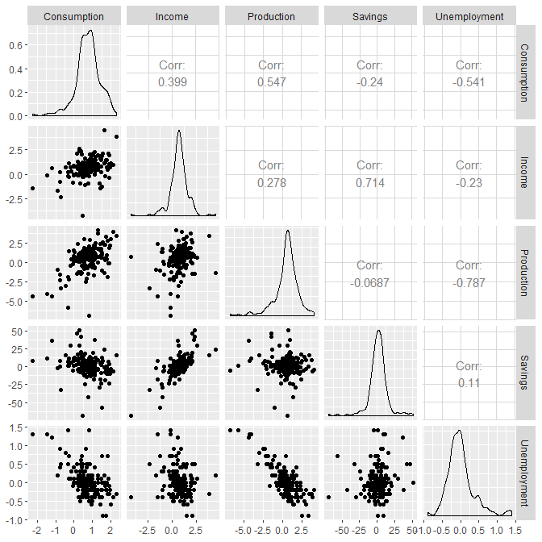

```r
uschange %>%
  as.data.frame() %>%
  GGally::ggpairs()
```

### 2.1.3 Assumptions

When we use a linear regression model, we are implicitly making some assumptions about the variables in Equation @ref(eq:lm).

First, we assume that the model is a reasonable approximation to reality; that is, that the relationship between the forecast variable and the predictor variables satisfies this linear equation.

Second, we make the following assumptions about the errors $(\varepsilon_{1},\dots,\varepsilon_{T})$:

- they have mean zero; otherwise the forecasts will be systematically biased.
- they are not autocorrelated; otherwise the forecasts will be inefficient as there is more information to be exploited in the data.
- they are unrelated to the predictor variables; otherwise there would be more information that should be included in the systematic part of the model.

It is also useful to have the errors are normally distributed with constant variance $sigma^2$ in order to easily produce prediction intervals.

Another improtant assumption in the linear regression model is that each predictor $x$ is not a random variable. If we are performing a controlled experiement in a lab, we could control the values of each $x$ (so they would not be random) and observe the resulting values of $y$. With observational data (including most data in business and economics) it is not possible to control the value of $x$, and hence we make this an assumption.

## 2.2 Least square estimation

In practice, of course, we have a collection of observations but we do not know the values of the coefficients $\beta_0,\beta_1, \dots, \beta_k$. These need to be estimated from the data.

The least squares principle provides a way of choosing the coefficients effectively by minimizing the sum of the squared errors. That is, we choose the values of $\beta_0, \beta_1, \dots, \beta_k$ that minimize
$$\sum_{t=1}^T \varepsilon_t^2 = \sum_{t=1}^T (y_t -
\beta_{0} - \beta_{1} x_{1,t} - \beta_{2} x_{2,t} - \cdots - \beta_{k} x_{k,t})^2.$$

This is called “least squares” estimation because it gives the least value for the sum of squared errors. Finding the best estimates of the coefficients is often called “fitting” the model to the data, or sometimes “learning” or “training” the model. The line shown in Figure @ref(fig:ConsInc2) was obtained in this way.

When we refer to the *estimated* coefficients, we will use the notation $\hat\beta_0, \dots, \hat\beta_k$. The equations for these will be given in Section @ref(Regr-MatrixEquations).

The `tslm` function fits a linear regression model to time series data. It is very similar to the `lm` function which is widely used for linear models, but `tslm` provides additional facilities for handling time series.

### 2.2.1 Example: US consumption on expenditure (revisited)

where $y$ is the percentage change in real personal consumption expenditure,  
$x_1$ is the percentage change in real personal disposable income, $x_2$ is the percentage change in industrial production, $x_3$ is the percentage change in personal savings and $x_4$ is the change in the unemployment rate.

The following output provides information about the fitted model. The first column of Coefficients gives an estimate of each $\beta$ coefficient and the second column gives its standard error (i.e., the standard deviation which would be obtained from repeatedly estimating the $\beta$ coefficients on similar data sets). The standard error gives a measure of the uncertainty in the estimated  
$\beta$ coefficient.

```r
fit.consMR <- tslm(
  Consumption~Income+Production+Unemployment+Savings,
  data=uschange
)
summary(fit.consMR)
```

```
Call:
tslm(formula = Consumption ~ Income + Production + Unemployment +
    Savings, data = uschange)

Residuals:
     Min       1Q   Median       3Q      Max
-0.88296 -0.17638 -0.03679  0.15251  1.20553

Coefficients:
             Estimate Std. Error t value Pr(>|t|)
(Intercept)   0.26729    0.03721   7.184 1.68e-11 ***
Income        0.71449    0.04219  16.934  < 2e-16 ***
Production    0.04589    0.02588   1.773   0.0778 .
Unemployment -0.20477    0.10550  -1.941   0.0538 .
Savings      -0.04527    0.00278 -16.287  < 2e-16 ***
---
Signif. codes:  0 ‘***’ 0.001 ‘**’ 0.01 ‘*’ 0.05 ‘.’ 0.1 ‘ ’ 1

Residual standard error: 0.3286 on 182 degrees of freedom
Multiple R-squared:  0.754, Adjusted R-squared:  0.7486
F-statistic: 139.5 on 4 and 182 DF,  p-value: < 2.2e-16
```

For forecasting purposes, the final two columns are of limited interest. The “t value” is the ratio of an estimated $\beta$ coefficient to its standard error and the last column gives the p-value: the probability of the estimated $\beta$ coefficient being as large as it is if there was no real relationship between consumption and the corresponding predictor. This is useful when studying the effect of each predictor, but is not particularly useful for forecasting.

### Fitter values

Predictions of $y$ can be obtained by using the estimated coefficients in the regression equation and setting the error term to zero. In general we write,
$$\begin{equation}
\hat{y}_t = \hat\beta_{0} + \hat\beta_{1} x_{1,t} + \hat\beta_{2} x_{2,t} + \cdots + \hat\beta_{k} x_{k,t}.
(\#eq:prediction)
\end{equation}$$

Plugging in the values of $x_{1,t},\ldots,x_{k,t}$ for $t=1,\ldots,T$ returns predictions of $y$ within the training-sample, referred to as *fitted values*. Note that these are predictions of the data used to estimate the model not genuine forecasts of future values of $y$.

The following plots show the actual values compared to the fitted values for the percentage change in the US consumption expenditure series. The time plot in Figure @ref(fig:usfitted1) shows that the fitted values follow the actual data fairly closely. This is verified by the strong positive relationship shown by the scatterplot in Figure @ref(fig:usfitted2).

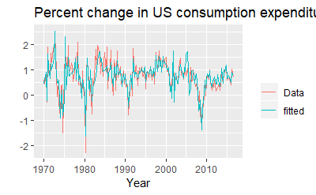

```r
autoplot(uschange[,"Consumption"],series="Data")+
  autolayer(fitted(fit.consMR),series="fitted")+
  labs(x="Year",y="")+
  ggtitle("Percent change in US consumption expenditure")+
  guides(color=guide_legend(title=" "))
```

```r
fit.consMR %>% summary()
```

```
Call:
tslm(formula = Consumption ~ Income + Production + Unemployment +
    Savings, data = uschange)

Residuals:
     Min       1Q   Median       3Q      Max
-0.88296 -0.17638 -0.03679  0.15251  1.20553

Coefficients:
             Estimate Std. Error t value Pr(>|t|)
(Intercept)   0.26729    0.03721   7.184 1.68e-11 ***
Income        0.71449    0.04219  16.934  < 2e-16 ***
Production    0.04589    0.02588   1.773   0.0778 .
Unemployment -0.20477    0.10550  -1.941   0.0538 .
Savings      -0.04527    0.00278 -16.287  < 2e-16 ***
---
Signif. codes:  0 ‘***’ 0.001 ‘**’ 0.01 ‘*’ 0.05 ‘.’ 0.1 ‘ ’ 1

Residual standard error: 0.3286 on 182 degrees of freedom
Multiple R-squared:  0.754, Adjusted R-squared:  0.7486
F-statistic: 139.5 on 4 and 182 DF,  p-value: < 2.2e-16
```

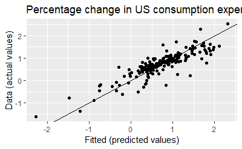

```r
cbind(Data=uschange[,"Consumption"], Fitted=fitted(fit.consMR)) %>%
  as.data.frame() %>%
  ggplot(aes(x=Data, y=Fitted)) +
    geom_point() +
    xlab("Fitted (predicted values)") +
    ylab("Data (actual values)") +
    ggtitle("Percentage change in US consumption expenditure") +
    geom_abline(intercept=0, slope=1)
```

### 2.2.2 Goodness of fit

A common way to summarise how well a linear regression model fits the data is via the coefficient of determination, or $R^2$. This can be calculated as the square of the correlation between the observed $y$ values and the predicted $^y$ values. Alternatively, it can also be calculated as,
$$R^2 = \frac{\Sigma{(\hat{y}-\overline{y})^2}}{\Sigma(y_t-\overline{y})^2}$$

$$R^2 = \frac{\sum(\hat{y}_{t} - \bar{y})^2}{\sum(y_{t}-\bar{y})^2}$$

where the summations are over all observations. Thus, it reflects the proportion of variation in the forecast variable that is accounted for (or explained) by the regression model.

In simple linear regression, the value of $R^2$ is also equal to the square of the correlation between $y$ and $x$ (provided an intercept has been included).

If the predictions are close to the actual values, we would expect $R^2$ to be close to 1. On the other hand, if the predictions are unrelated to the actual values, then $R^2=0$ (again, assuming there is an intercept). In all cases, $R^2$ lies between 0 and 1.

The $R^2$ value is commonly used, often incorrectly, in forecasting. $R^2$ will never decrease when adding an extra predictor to the model and this can lead to over-fitting. There are no set rules for what is a good $R^2$ value, and typical values of $R^2$ depend on the type of data used. Validating a model’s forecasting performance on the test data is much better than measuring the $R^2$ value on the training data.

#### Example

Recall the example of US consumption data discussed in Section @ref(Regr-LSprinciple). The output for the estimated model is reproduced here for convenience:

```r
fit.consMR <- tslm(Consumption ~ Income + Production + Unemployment + Savings,
  data=uschange)
summary(fit.consMR)
```

```
Call:
tslm(formula = Consumption ~ Income + Production + Unemployment +
    Savings, data = uschange)

Residuals:
     Min       1Q   Median       3Q      Max
-0.88296 -0.17638 -0.03679  0.15251  1.20553

Coefficients:
             Estimate Std. Error t value Pr(>|t|)
(Intercept)   0.26729    0.03721   7.184 1.68e-11 ***
Income        0.71449    0.04219  16.934  < 2e-16 ***
Production    0.04589    0.02588   1.773   0.0778 .
Unemployment -0.20477    0.10550  -1.941   0.0538 .
Savings      -0.04527    0.00278 -16.287  < 2e-16 ***
---
Signif. codes:  0 ‘***’ 0.001 ‘**’ 0.01 ‘*’ 0.05 ‘.’ 0.1 ‘ ’ 1

Residual standard error: 0.3286 on 182 degrees of freedom
Multiple R-squared:  0.754, Adjusted R-squared:  0.7486
F-statistic: 139.5 on 4 and 182 DF,  p-value: < 2.2e-16
```

[output not shown]

Figure @ref(fig:usfitted2) plots the actual consumption expenditure values versus the fitted values. The correlation between these variables is $r=0.868$ hence $R^2= 75.4$% (shown in the output above). In this case model does an excellent job as it explains most of the variation in the consumption data. Compare that to the $R^2$ value of 16% obtained from the simple regression with the same data set in Section @ref(Regr-Intro). Adding the three extra predictors has allowed a lot more of the variance in the consumption data to be explained.

### 2.2.3 Standard error of the regression

Another measure of how well the model has fitted the data is the standard deviation of the residuals, which is often known as the “residual standard error”. This is shown in the above output with the value 0.3286.

It is calculated by
$$\begin{equation}
\hat{\sigma}_e=\sqrt{\frac{1}{T-k-1}\sum_{t=1}^{T}{e_t^2}}.
(\#eq:Regr-se)
\end{equation}$$

Notice that here we divide by $T-k-1$ in order to account for the number of estimated parameters in computing the residuals. Normally, we only estimate the mean (i.e., one parameter) when computing a standard deviation. The divisor is always $T$ minus the number of parameters estimated in the calculation. Here, we divide by $T−k−1$ because we have estimated $k+1$ parameters (the intercept and a coefficient for each predictor variable) in computing the residuals.

The standard error is related to the size of the average error that the model produces. We can compare this error to the sample mean of $y$ or with the standard deviation of $y$ to gain some perspective on the accuracy of the model.

We should warn here that the evaluation of the standard error can be highly subjective as it is scale dependent. The main reason we introduce it here is that it is required when generating prediction intervals, discussed in Section @ref(Regr-ForeWithRegr).

## 2.3 Evaluating the regression model

The difference between the observied $y$ values and the corresponding fitted $\hat{y}$ values are the trainig set errors or “residuals” defined as,

$$\begin{align*}
e_t &= y_t - \hat{y}_t \\
&= y_t - \hat\beta_{0} - \hat\beta_{1} x_{1,t} - \hat\beta_{2} x_{2,t} - \cdots - \hat\beta_{k} x_{k,t}
\end{align*}$$

for $t=1,\ldots,T$. Each residual is the unpredictable component of the associated observation.

The residuals have some useful properties including the following two:
$$\sum_{t=1}^{T}{e_t}=0 \quad\text{and}\quad \sum_{t=1}^{T}{x_{k,t}e_t}=0\qquad\text{for all $k$}.$$

As a result of these properties, it is clear that the average of the residual is zero, and that the correlation between the residuals and the observations for the predictor variable is also zero. (This is not necessarily true when the intercept is omitted from the model.)

After selecting the regression variables and fitting a regression model, it is necessary to plot the residuals to check that the assumptions of the model have been satisfied. There are a series of plots that should be produced in order to check different aspects of the fitted model and the underlying assumptions.

### 2.3.1 ACF plot of residuals

With time series data, it is highly likely that the value of a variable observed in the current time period will be similar to its value in the previous period, or even the period before that, and so on. Therefore when fitting a regression model to time series data, it is very common to find *autocorrelation* in the residuals. In this case, the estimated model violates the assumption of no autocorrelation in the errors, and our forecasts may be inefficient — there is some information left over which should be accounted for in the model in order to obtain better forecasts. The forecasts from a model with autocorrelated errors are still unbiased, and so are not “wrong”, but they will usually have larger prediction intervals than they need to. Therefore we should always look at an ACF plot of the residuals.

Another useful test of *autocorrelation* in the residuals designed to take account for the regression model is the **Breusch-Godfrey** test, also referred to as the LM (Lagrange Multiplier) test for *serial correlation*. It is used to test the joint hypothesis that there is no autocorrelation in the residuals up to a certain specified order. A small p-value indicates there is significant autocorrelation remaining in the residuals.

The Breusch-Godfrey test is similar to the Ljung-Box test, but it is specifically designed for use with regression models.

### 2.3.2 Histograms of residuals

It is always a good idea to check if the residuals are normally distributed. As explained earlier, this is not essential for forecasting, but it does make the calcultion of prediction intervals much easier.

#### 2.3.2.1 Example

```
    Breusch-Godfrey test for serial correlation of order up to 8

data:  Residuals from Linear regression model
LM test = 14.874, df = 8, p-value = 0.06163
```

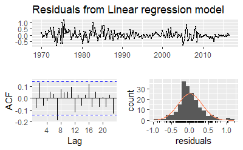

```r
checkresiduals(fit.consMR)
```

Figure 5.8 shows a time plot, the ACF and the histogram of the residuals from the multiple regression model fitted to the US quarterly consumption data, as well as the Breusch-Godfrey test for jointly testing up to 8th order autocorrelation. (The `checkresiduals()` function will use the *Breusch-Godfrey* test for regression models, but the Ljung-Box test otherwise.)

The timeplot shows some changin variation over time, but is otherwise relatively unremakable. This *heteroschedasticity* will potentially make potentially make the prediction interval coverage inaccurate.

The histogram shows that the residuals seem to be slightly *skewed*, which may also affect the coverage probability of the prediction intervals.

The autocorrelation plot shows a significant spike at lag 7, but it is not quite enough for the ***Breusch-Godfrey** to be significantly at the 5% level. In any case, the autocorrelation is not particularly large, and lag 7 it is unlikely to have any noticeable impact on the forecasts or the prediction intervals. In Chapter 9, we discuss dynamic regression modesl used for better capturing information left in the residuals.

### Residual plots against predictors

We would expect the residuals to be randomly scattered without showing any systematic patterns. A simple and quick way to check this is to examine *scatterplots* of the residuals against each of the predictor variables. If these scatterplots show a pattern, then the relationship may be nonlinear and the model will need to be modified accordingly. See Section 5.8 for a discussion of nonlinear regression.

It is also necessary to plot the residuals against any predictors that are not in the model. If any of these *show a pattern*, then the corresponding predictor may need to be added to the model (possibly in a nonlinear form).

#### 2.3.2.2 Example

The residuals from the multiple regression model for forecasting US consumption plotted against each predictor in Figure 5.9 seem to be randomly scattered. Therefore we are satisfied with these in this case.

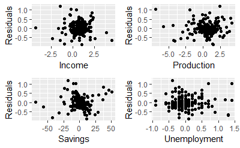

```r
df <- as.data.frame(uschange)
df[,"Residuals"] <- as.numeric(residuals(fit.consMR))
p1 <- ggplot(df,aes(Income,Residuals))+geom_point()
p2 <- ggplot(df,aes(Production,Residuals))+geom_point()
p3 <- ggplot(df,aes(Savings, Residuals))+geom_point()
p4 <- ggplot(df,aes(Unemployment, Residuals))+geom_point()
gridExtra::grid.arrange(p1,p2,p3,p4, nrow=2)
```

### 2.3.3 Residual plots against fitted values

A plot of the residuals against the fitted value should also show no pattern. If a pattern is observed, there may be “heteroskedasticity” in the errors which means that the variance of the residuals may not be constant. If this problem occurs, a transformation of the forecast variable such as a logarithm or square root may be required.

#### 2.3.3.1 Example

Continuing the previous example, Figure 5.10 shows the residuals plotted against the fitted values. The random scatter suggests the errors are **homoscedastic**.

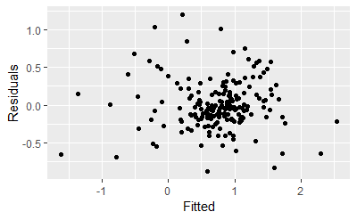

```r
cbind(Fitted=fitted(fit.consMR),
      Residuals=residuals(fit.consMR)) %>%
  as.data.frame() %>%
  ggplot(aes(Fitted,Residuals))+geom_point()
```

### Outliers and influential observations

Observations that take extreme values compared to the majority of the data are called **outliers**. Observations that have a large influence on the estimated coefficients of a regression model are called **influential observations**. Usually, influential observations are also outliers that are extreme in the $x$ direction.

There are formal methods for detecting outliers and influential observations that are beyond the scope of this book. As we suggested at the beginning of Chapter 2, becoming faimilar with your data prior to perfoming any analysis of vital importance. A scatter plot of $y$ against each $x$ is always a useful point in regression analysis, and often helps to identify usual observations.

One source of outliers is *incorrect data entry*. Simple descriptive statistics of your data can identify minima and maxima that are sensible. If such an observation is identified, and it has been recored incorrectly, it should be corrected or removed from the sample immediately.

Outliers also occur when some observations are simply different. In this case it may not be wise for these observations to be removed. IF an observation has been identified as a likely outlier, it is important to study it and analyze the possible reasons behind it. The decision to remove or retain an observation can be a challenging one (especially when outliers are influential observations). It is wise to report results both with and without the removal of such observations.

#### 2.3.3.2 Example

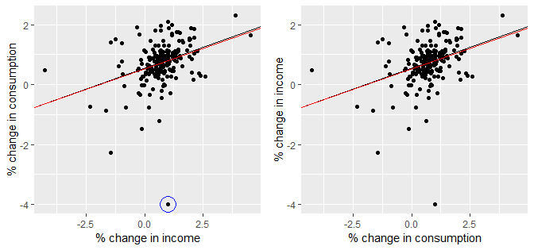

### 2.3.4 Spurious regression

More often than not, time series data are **“non-stationary”**; that is, the values of the time series do not fluctuate around a constant mean or with a constant variance. We will deal with time series stationarity in more detail in Chapter 8, but here we need to address the effect that non-stationary data can have on regression models.

For example consider the two variables plotted below in Figure @ref(fig:spurious). These appear to be related simply because they both trend upwards in the same manner. However, air passenger traffic in Australia has nothing to do with rice production in Guinea.

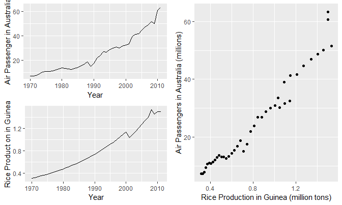

Regressing *non-stationary* time series can lead to **spurious regressions**. The output of regressing Australian air passengers on rice production in Guinea is shown below. High $R^2$ and **high residual autocorrelation** can be signs of **spurious regression**. We discuss the issues surrounding non-stationary data and spurious regressions in more detail in Chapter @ref(ch-dynamic).

Cases of spurious regression might appear to give reasonable short-term forecasts, but they will generally not continue to work into the future.

```r
aussies <- window(ausair, end=2011)
fit <- tslm(aussies~guinearice)
summary(fit)
```

```
Call:
tslm(formula = aussies ~ guinearice)

Residuals:
    Min      1Q  Median      3Q     Max
-5.9448 -1.8917 -0.3272  1.8620 10.4210

Coefficients:
            Estimate Std. Error t value Pr(>|t|)
(Intercept)   -7.493      1.203  -6.229 2.25e-07 ***
guinearice    40.288      1.337  30.135  < 2e-16 ***
---
Signif. codes:  0 ‘***’ 0.001 ‘**’ 0.01 ‘*’ 0.05 ‘.’ 0.1 ‘ ’ 1

Residual standard error: 3.239 on 40 degrees of freedom
Multiple R-squared:  0.9578,    Adjusted R-squared:  0.9568
F-statistic: 908.1 on 1 and 40 DF,  p-value: < 2.2e-16
```

```
    Breusch-Godfrey test for serial correlation of order up to 8

data:  Residuals from Linear regression model
LM test = 28.813, df = 8, p-value = 0.000342
```

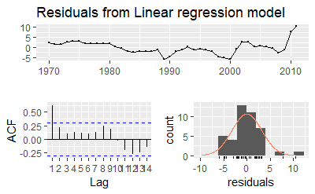

```r
checkresiduals(fit)
```

## 2.4 Selection predictors

When there are many possible predictors, we need some strategy to select the best predictors to use in a regression model.

A common approach that is *not recommended* is to plot the forecast variable against a particular predictor and if it shows no noticeable relationship, drop it. This is invalid because it is not always possible to see the relationship from a scatterplot, especially when the effects of other predictors have not been accounted for.

Another common approach which is also invalid is to do a multiple linear regression on all the predictors and disregard all variables whose $p$-values are greater than 0.05. To start with, statistical significance does not always indicate predictive value. Even if forecasting is not the goal, this is not a good strategy because the $p$-values can be misleading when two or more predictors are correlated with each other (see Section @ref(Regr-MultiCol)).

## 2.5 Some useful predictors

There are several useful predictors that occur frequently when using regression for time series data.

### 2.5.1 Trend

It is very common for time series data to be trending. A linear trend can be modelled by simply using $x_{1,t}=t$ as a predictor,
$$y_{t}= \beta_0+\beta_1t+\varepsilon_t$$

where $t=1,\dots,T$. A trend variable can be specified in the `tslm` function using the `trend` predictor. In Section @ref(Regr-NonLinear) we discuss how we can also model a nonlinear trends.

### 2.5.2 Dummy variables

So far, we have assumed that each predictor takes numerical values. But what about when a predictor is a categorical variable taking only two values (e.g., “yes” and “no”). Such a variable might arise, for example, when forecasting daily sales and you want to take account of whether the day is a **public holiday** or not. So the predictor takes value “yes” on a public holiday, and “no” otherwise.

This situation can still be handled within the framework of multiple regression models by creating a “dummy variable” taking value 1 corresponding to “yes” and 0 corresponding to “no”. A dummy variable is also known as an “indicator variable”.

A dummy variable can also be used to account for an **outlier** in the data. Rather than omit the outlier, a dummy variable removes its effect. In this case, the dummy variable takes value 1 for that observation and 0 everywhere else. An example is the case where a special event has occurred. For example when forecasting tourist arrivals to Brazil, we will need to account for the effect of the Rio de Janeiro summer Olympics in 2016.

If there are more than two categories, then the variable can be coded using several dummy variables (one fewer than the total number of categories). `tslm` will automatically handle this case if you specify a factor variable as a predictor. There is usually no need to manually create the corresponding dummy variables.

### 2.5.3 Seasonal dummy varabiles

For example, suppose we are forecasting daily electricity demand and we want to account for the day of the week as a predictor. Then the following dummy variables can be created.

|  | *d*<sub>1, *t*</sub> | *d*<sub>2, *t*</sub> | *d*<sub>3, *t*</sub> | *d*<sub>4, *t*</sub> | *d*<sub>5, *t*</sub> | *d*<sub>6, *t*</sub> |
| --- | --- | --- | --- | --- | --- | --- |
| Monday | 1 | 0 | 0 | 0 | 0 | 0 |
| Tuesday | 0 | 1 | 0 | 0 | 0 | 0 |
| Wednesday | 0 | 0 | 1 | 0 | 0 | 0 |
| Thursday | 0 | 0 | 0 | 1 | 0 | 0 |
| Friday | 0 | 0 | 0 | 0 | 1 | 0 |
| Saturday | 0 | 0 | 0 | 0 | 0 | 1 |
| Sunday | 0 | 0 | 0 | 0 | 0 | 0 |
| Monday | 1 | 0 | 0 | 0 | 0 | 0 |
| Tuesday | 0 | 1 | 0 | 0 | 0 | 0 |
| Wednesday | 0 | 0 | 1 | 0 | 0 | 0 |
| Thursday | 0 | 0 | 0 | 1 | 0 | 0 |
| Friday | 0 | 0 | 0 | 0 | 1 | 0 |
| ⋮ | ⋮ | ⋮ | ⋮ | ⋮ | ⋮ | ⋮ |

Notice that only six dummy variables are needed to code seven categories. That is because the seventh category (in this case Sunday) is specified when all dummy variables are all set to zero and is captured by the intercept.

Many beginners will try to add a seventh dummy variable for the seventh category. This is known as the “dummy variable trap” because it will cause the regression to fail. There will be one too many parameters to estimate when an intercept is also included. The general rule is to use one fewer dummy variables than categories. So for quarterly data, use three dummy variables; for monthly data, use 11 dummy variables; and for daily data, use six dummy variables, and so on.

The interpretation of each of the coefficients associated with the dummy variables is that it is *a measure of the effect of that category relative to the omitted category*. In the above example, the coefficient of $d_{1,t}$ associated with Monday will measure the effect of Monday compared to Sunday on the forecast variable. An example of interpreting estimated dummy variable coefficients capturing the quarterly seasonality of Australian beer production follows.

The `tslm` function will automatically handle this situation if you specify the predictor `season`.

#### Example Australian quarterly beer production

Recall the Australian quarterly beer production data shown again in Figure @ref(fig:beeragain) below.

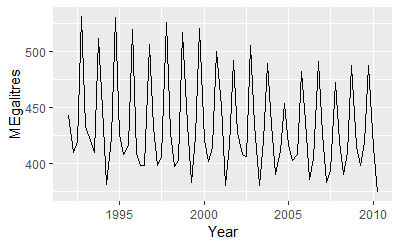

```r
beer2 <- window(ausbeer,start=1992)
autoplot(beer2)+xlab("Year")+ylab("MEgalitres")
```

We want to forecast the value of future beer production. We can model this data using a regression model with a linear trend and quarterly dummy variables.
$$y_{t} = \beta_{0} + \beta_{1} t + \beta_{2}d_{2,t} + \beta_3 d_{3,t} + \beta_4 d_{4,t} + \varepsilon_{t},$$
where $d_{i,t} = 1$ if $t$ is in quarter $i$ and 0 otherwise. The first quarter variable has been omitted, so the coefficients associated with the other quarters are measures of the difference between those quarters and the first quarter.

```r
fit.beer <- tslm(beer2 ~ trend + season)
summary(fit.beer)
```

```
Call:
tslm(formula = beer2 ~ trend + season)

Residuals:
    Min      1Q  Median      3Q     Max
-42.903  -7.599  -0.459   7.991  21.789

Coefficients:
             Estimate Std. Error t value Pr(>|t|)
(Intercept) 441.80044    3.73353 118.333  < 2e-16 ***
trend        -0.34027    0.06657  -5.111 2.73e-06 ***
season2     -34.65973    3.96832  -8.734 9.10e-13 ***
season3     -17.82164    4.02249  -4.430 3.45e-05 ***
season4      72.79641    4.02305  18.095  < 2e-16 ***
---
Signif. codes:  0 ‘***’ 0.001 ‘**’ 0.01 ‘*’ 0.05 ‘.’ 0.1 ‘ ’ 1

Residual standard error: 12.23 on 69 degrees of freedom
Multiple R-squared:  0.9243,    Adjusted R-squared:  0.9199
F-statistic: 210.7 on 4 and 69 DF,  p-value: < 2.2e-16
```

Note that `trend` and `season` are not objects in the R workspace; they are created automatically by `tslm` when specified in this way.

There is a downward trend of -0.34 megalitres per quarter. On average, the second quarter has production of 34.7 megalitres lower than the first quarter, the third quarter has production of 17.8 megalitres lower than the first quarter, and the fourth quarter has production of 72.8 megalitres higher than the first quarter.

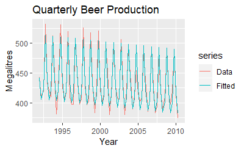

```r
autoplot(beer2, series="Data")+
  autolayer(fitted(fit.beer),series="Fitted")+
  xlab("Year")+ylab("Megalitres")+
  ggtitle("Quarterly Beer Production")
```

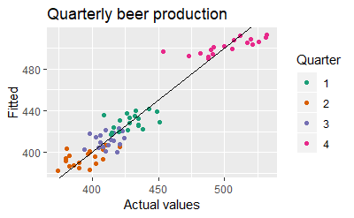

```r
cbind(Data=beer2, Fitted=fitted(fit.beer)) %>%
  as.data.frame() %>%
  ggplot(aes(x=Data,y=Fitted, colour=as.factor(cycle(beer2))))+
  geom_point()+
  ylab("Fitted")+xlab("Actual values")+
  ggtitle("Quarterly beer production")+
  scale_color_brewer(palette="Dark2",name="Quarter")+
  geom_abline(intercept=0, slope=1)
```

### 2.5.4 Intervention variables

It is often necessary to model interventions that may have affected the variable to be forecast. For example, competitor activity, advertising expenditure, industrial action, and so on, can all have an effect.

When the effect lasts only for one period, we use a spike variable. This is a dummy variable taking value one in the period of the intervention and zero elsewhere. A spike variable is equivalent to a dummy variable for handling an outlier.

Other interventions have an immediate and permanent effect. If an intervention causes a level shift (i.e., the value of the series changes suddenly and permanently from the time of intervention), then we use a step variable. A step variable takes value zero before the intervention and one from the time of intervention onward.

Another form of permanent effect is a change of slope. Here the intervention is handled using a piecewise linear trend; a trend that bends at the time of intervention and hence is nonlinear. We will discuss this in Section @ref(Regr-NonLinear).

### Trading days

The number of trading days in a month can vary considerably and can have a substantial effect on sales data. To allow for this, the number of trading days in each month can be included as a predictor.

For monthly or quarterly data, the `bizdays` function will compute the number of trading days in each period.

An alternative that allows for the effects of different days of the week has the following predictors:
$$\begin{align*}
x_{1} &= \text{# Mondays in month;} \\
x_{2} &= \text{# Tuesdays in month;} \\
& \vdots \\
x_{7} &= \text{# Sundays in month.}
\end{align*}$$

### Distributed lags

It is often useful to include advertising expenditure as a predictor. However, since the effect of advertising can last beyond the actual campaign, we need to include lagged values of advertising expenditure. So the following predictors may be used.
$$\begin{align*}
x_{1} &= \text{advertising for previous month;} \\
x_{2} &= \text{advertising for two months previously;} \\
& \vdots \\
x_{m} &= \text{advertising for $m$ months previously.}
\end{align*}$$

It is common to require the coefficients to decrease as the lag increases, although this is beyond the scope of this book.

### Easter

Easter is different from most holidays because it is not held on the same date each year and the effect can last for several days. In this case, a dummy variable can be used with value one where the holiday falls in the particular time period and zero otherwise.

For example, with monthly data, when Easter falls in March then the dummy variable takes value 1 in March, when it falls in April, the dummy variable takes value 1 in April, and when it starts in March and finishes in April, the dummy variable is split proportionally between months.

The `easter` function will compute the dummy variable for you.

### Fourier series

As alternative to using seasonal dummy variables, especially for long seasonal periods, is to use **Fourier terms**. Jean-Baptiste Fourier was a French mathmatician, born in the 1700s, who showed that a series of sine and cosine terms of the right frequencies can approximate any periodic function. We can use them for seasonal patterns.

If $m$ is the seasonal period, then the first few Fourier terms are given by
$$x_{1,t} = \sin\left(\textstyle\frac{2\pi t}{m}\right),
x_{2,t} = \cos\left(\textstyle\frac{2\pi t}{m}\right),
x_{3,t} = \sin\left(\textstyle\frac{4\pi t}{m}\right),
x_{4,t} = \cos\left(\textstyle\frac{4\pi t}{m}\right),
x_{5,t} = \sin\left(\textstyle\frac{6\pi t}{m}\right),
x_{6,t} = \cos\left(\textstyle\frac{6\pi t}{m}\right),$$

and so on. If we have monthly seasonality, and we use the first 11 of these predictor variables, then we will get exactly the same forecasts as using 11 dummy variables.

The advantage of using Fourier terms is that we can often use fewer predictor variables than we need to with dummy variables, especially when $m$ is large. This makes them useful for weekly data, for example, where $m\approx 52$. For short seasonal periods such as with quarterly data, there is little advantage in using Fourier series over seasonal dummy variables.

In R, these Fourier terms are produced using the `fourier` function. For example, the Australian beer data can be modelled like this.

```r
fourier.beer <- tslm(beer2~trend+fourier(beer2, K=2))
summary(fourier.beer)
```

```
Call:
tslm(formula = beer2 ~ trend + fourier(beer2, K = 2))

Residuals:
    Min      1Q  Median      3Q     Max
-42.903  -7.599  -0.459   7.991  21.789

Coefficients:
                           Estimate Std. Error t value Pr(>|t|)
(Intercept)               446.87920    2.87321 155.533  < 2e-16 ***
trend                      -0.34027    0.06657  -5.111 2.73e-06 ***
fourier(beer2, K = 2)S1-4   8.91082    2.01125   4.430 3.45e-05 ***
fourier(beer2, K = 2)C1-4  53.72807    2.01125  26.714  < 2e-16 ***
fourier(beer2, K = 2)C2-4  13.98958    1.42256   9.834 9.26e-15 ***
---
Signif. codes:  0 ‘***’ 0.001 ‘**’ 0.01 ‘*’ 0.05 ‘.’ 0.1 ‘ ’ 1

Residual standard error: 12.23 on 69 degrees of freedom
Multiple R-squared:  0.9243,    Adjusted R-squared:  0.9199
F-statistic: 210.7 on 4 and 69 DF,  p-value: < 2.2e-16
```

The first argument to `fourier` just allows it to identify the seasonal period $m$ and the length of the predictors to return. The second `K` argument specifies how many pairs of sin and cos terms to include. The maximum number allowed is $K=m/2$ where $m$ is the seasonal period. Because we have used the maximum here, the results are identical to those obtained when using seasonal dummy variables.

If only the first two Fourier terms are used ($x_{1,t}$ and $x_{2,t}$), the seasonal pattern will follow a simple sine wave. A regression model containing Fourier terms is often called a **harmonic regression** because the successive Fourier terms represent harmonics of the first two Fourier terms.

## 2.6 Selecting predictors

When there are many possible predictors, we need some strategy for selecting the best predictors to use in a regression model.

A common approach that is *not recommended* is to plot the forecast variable against a particular predictor and if there is no noticebable relationship, drop that predictor from the model. This is invalid because it is not always possible to see the relationship from a scatter plot, especially when the effects of other predictors have not been accounted for.

Another common approach which is also invalid is to do a multiple linear regression on all the predictors and disregard all variables whose *p* values are greater than 0.05. To start with, statistical sigfinicance does not always indicate predictive value. Even if forecasting is not the goal, this is not a good strategy because the $p$-value can be misleading when two or more predictors are correlated with each other (see Section 5.9).

Instead, we will use a measure of predictive accuracy. Five such measures are introduced in this section. They can be calculated using the `cv()` function, here applied to the model for US consumption:

```r
CV(fit.consMR)
```

```
          CV          AIC         AICc          BIC        AdjR2
   0.1163477 -409.2980298 -408.8313631 -389.9113781    0.7485856
```

We compare these values against the corresponding values from other models. For the CV, AIC, AICc and BIC measures, we want to find the model with the lowest value; for adjusted $R^2$, we seek the model with the highest value.

### 2.6.1 Adjusted $R^2$

Computer output for a regression will always give the $R^2$ value, discussed in Section 5.2. However, it is not a good measure of the predictive ability of a model. Imagine a model which produces forecats that are exactly 20% of the actual values. In that case, the $R^2$ value would be 1 (indicating perfect correlation), but the forecasts are not very close to the actual values.

In addition, $R^2$ does not allow for “degrees of freedom”. Adding *any* variable tends to increase the value of $R^2$, even if that variable is irrelevant. For these reasons, forecasters should not use $R^2$ to determine whether a model will give good predictions.

An equivalent idea is to select the model which gives the minimum sum of squared errors (SSE), given by
$$\text{SSE} = \sum_{t=1}^T e_{t}^2.$$

Minimizing the SSE is equivalent to maximizing $R^2$ and will always choose the model with the most variables, and so is not a valid way of selecting predictors.

An alternative, designed to overcome these problems, is the adjusted $R^2$ (also called “R-bar-squared”):
$$\bar{R}^2 = 1-(1-R^2)\frac{T-1}{T-k-1},$$
where $T$ is the number of observations and $k$ is the number of predictors. This is an improvement on $R^2$ as it will no longer increase with each added predictor. Using this measure, the best model will be the one with the largest value of $\bar{R}^2$. Maximizing $\bar{R}^2$ is equivalent to minimizing the standard error $\hat{\sigma}_e$ given in Equation @ref(#eq:Regr-se).

Maximizing $\bar{R}^2$ works quite well as a method of selecting predictors, although it does tend to err on the side of selecting too many predictors.

### 2.6.2 Cross-validation

Section @ref(accuracy) introduced **time series cross-validation** as a general and useful tool for determining the predictive ability of a model. For regression models, it is also possible to use classical *leave-one-out cross-validation* to selection predictors [@BHK15]. This is faster and makes more efficient use of the data. The procedure uses the following steps:

1. Remove observation $t$ from the data set, and fit the model using the remining data. Then compute the error $e_t^* =y_t-\hat{y_t}$ for the omitted observation (This is not the same as the residual because the $t$th observation are not used in estimating the value of $\hat{y}_{t}$)
2. Repeat step1 for $t=1,\dots,T$.
3. Compute the MSE from $e_{1}^*,\dots,e_{T}^*$. We shall call this the **CV**.

Although this looks like a time-consuming procedure, there are fast methods of calculating `CV`, so that it takes no longer than fitting one model to the full data set. The equation for computing CV efficiently is given in Section 5.7. Under this criterion, the best model is the one with the smallest value of `CV`.

### 2.6.3 Akaike’S information criterion

A closely-related method os Akaike’s information citerion, which we define as

$$\text{AIC} = T\log\left(\frac{\text{SSE}}{T}\right) + 2(k+2),$$

where $T$ is the number of observations used for estimation and $k$ is the number of predictors in the model. Different computer packages use slightly different definitions for the AIC, although they should all lead to the same model being selected. The $k+2$ part of the equation occurs because there are $k+2$ parameters in the model: the $k$ coefficients for the predictors, the intercept and the variance of the residuals. The idea here is to penalize the fit of the model (SSE) with the number of parameters that need to be estimated.

The model with the minimum value of the AIC is often the best model for forecasting. For large values of $T$, minimizing the AIC is equivalent to minimizing the CV value.

### 2.6.4 Corrected Akaike’s information criterion

For small values of $T$, the AIC tends to select too many predictors, and so a bias-corrected version of the AIC has been developed,
$$\text{AIC}_{\text{c}} = \text{AIC} + \frac{2(k+2)(k+3)}{T-k-3}.$$

As with the AIC, the AICc should be minimized.

### 2.6.5 Schwarz bayesian information criterion

A related measure is Schwarz’s Bayesian Information Criterion (known as SBIC, BIC or SC),
$$\text{BIC} = T\log\left(\frac{\text{SSE}}{T}\right) + (k+2)\log(T).$$

As with the AIC, minimizing the BIC is intended to give the best model. The model chosen by BIC is either the same as that chosen by AIC, or one with fewer terms. This is because the BIC penalizes the number of parameters more heavily than the AIC. For large values of $T$, minimizing BIC is similar to leave-$v$-out cross-validation when $v = T[1-1/(\log(T)-1)]$.

### 2.6.6 Which measure should we use

While $R^2$ is widely used, and has been around longer than the other measures, its tendency to select too many predictor variables makes it less suitable for forecasting.

Many statisticians like to use the **BIC** because it has the feature that if there is a true underlying model, the BIC will select that model given enough data. However, in reality, there is rarely, if ever, a true underlying model, and even if there was a true underlying model, selecting that model will not necessarily give the best forecasts (because the parameter estimates may not be accurate).

Consequently, we recommend that one of the `AICc`, `AIC` or `CV` statistics be used, each of which has forecasting as their objective. If the value of $T$ is large enough, they will all lead to the same model. In most of the examples in this book, we use the AIcc value to select the forecasting model.

#### 2.6.6.1 Example: US consumption

To obtain all these measures in R, use `CV(fit)`. In the multiple regression example for forecasting US consumption we considered four predictors. With four predictors, there are $2^4=16$ possible models. Now we can check if all four predictors are actually useful, or whether we can drop one or more of them. All 16 models were fitted and the results are summarised below in Table @ref(tab:tblusMR). A “1” indicates that the predictor was included in the model, and a “0” means that the predictor was not included in the model. Hence the first row shows the measures of predictive accuracy for a model including all four predictors.

The results have been sorted according to the AICc and therefore the best models are given at the top of the table, and the worst at the bottom of the table.

| Income | Production | Savings | uneployment | CV | AIC | AICc | BIC | AdjR2 |
| --- | --- | --- | --- | --- | --- | --- | --- | --- |
| 1 | 1 | 1 | 1 | 0.116 | -409.298 | -408.831 | -389.911 | 0.749 |
| 1 | 0 | 1 | 1 | 0.116 | -408.094 | -407.763 | -391.939 | 0.746 |
| 1 | 1 | 1 | 0 | 0.118 | -407.467 | -407.135 | -391.311 | 0.745 |
| 1 | 0 | 1 | 0 | 0.129 | -388.727 | -388.507 | -375.803 | 0.716 |
| 1 | 1 | 0 | 1 | 0.278 | -243.164 | -242.832 | -227.008 | 0.386 |
| 1 | 0 | 0 | 1 | 0.283 | -237.928 | -237.708 | -225.003 | 0.365 |
| 1 | 1 | 0 | 0 | 0.289 | -236.125 | -235.906 | -223.201 | 0.359 |
| 0 | 1 | 1 | 1 | 0.293 | -234.373 | -234.042 | -218.218 | 0.356 |
| 0 | 1 | 1 | 0 | 0.300 | -228.942 | -228.722 | -216.018 | 0.334 |
| 0 | 1 | 0 | 1 | 0.303 | -226.298 | -226.078 | -213.374 | 0.324 |
| 0 | 0 | 1 | 1 | 0.306 | -224.575 | -224.355 | -211.650 | 0.318 |
| 0 | 1 | 0 | 0 | 0.314 | -219.627 | -219.496 | -209.934 | 0.296 |
| 0 | 0 | 0 | 1 | 0.314 | -217.677 | -217.546 | -207.984 | 0.288 |
| 1 | 0 | 0 | 0 | 0.372 | -185.438 | -185.307 | -175.744 | 0.154 |
| 0 | 0 | 1 | 0 | 0.414 | -164.135 | -164.004 | -154.442 | 0.052 |
| 0 | 0 | 0 | 0 | 0.432 | -155.051 | -154.985 | -148.588 | 0.000 |

The best model contains all four predictors. However, a closer look at the results reveals some interesting features. There is clear separation between the models in the first four rows and the ones below. This indicates that Income and Savings are both more important variables than Production and Unemployment. Also, the first two rows have almost identical values of *CV*, *AIC* and *AICc*. So we could possibly drop the Production variable and get very similar forecasts. Note that Production and Unemployment are highly (negatively) correlated, as shown in Figure @ref(fig:ScatterMatrix), so most of the predictive information in Production is also contained in the Unemployment variable.

### 2.6.7 Best subset regression

Where possible, all potential regression models should be fitted (as was done in the above example) and the best model should be selected based on one of the measures discussed. This is known as “best subsets” regression or “all possible subsets” regression.

It is recommended that one of CV, AIC or AICc be used for this purpose. If the value of $T$ is large enough, they will all lead to the same model.

While $\bar{R}^2$ is very widely used, and has been around longer than the other measures, its tendency to select too many predictor variables makes it less suitable for forecasting than either CV, AIC or AICc. Also, the tendency of BIC to select too few variables makes it less suitable for forecasting than either CV, AIC or AICc.

### 2.6.8 Stepwise regression

If there are a large number of predictors, it is not possible to fit all possible models. For example, 40 predictors leads to $2^{40} >$ 1 trillion possible models! Consequently, a strategy is required to limit the number of models to be explored.

An approach that works quite well is *backwards stepwise regression*:

- Start with the model containing all potential predictors.
- Remove one predictor at a time. Keep the model if it improves the measure of predictive accuracy.

If the number of potential predictors is too large, then the backwards stepwise regression will not work and *forward stepwise regression* can be used instead. This procedure starts with a model that includes only the intercept. Predictors are added one at a time, and the one that most improves the measure of predictive accuracy is retained in the model. The procedure is repeated until no further improvement can be achieved.

Alternatively for either the backward or forward direction, a starting model can be one that includes a subset of potential predictors. In this case, an extra step needs to be included. For the backwards procedure we should also consider adding a predictor with each step, and for the forward procedure we should also consider dropping a predictor with each step. These are referred to as *hybrid* procedures.

It is important to realise that any stepwise approach is not guaranteed to lead to the best possible model, but it almost always leads to a good model. For further details see [@ISLR.](https://www-bcf.usc.edu/~gareth/ISL/)

### 2.6.9 Beware of inference after selecting predictors

We do not discuss statistical inference of the predictors in this book (e.g., looking at $p$-values associated with each predictor). If you do wish to look at the statistical significance of the predictors, beware that *any* procedure involving selecting predictors first will invalidate the assumptions behind the $p$-values. The procedures we recommend for selecting predictors are helpful when the model is used for forecasting; they are not helpful if you wish to study the effect of any predictor on the forecast variable.

## 2.7 Forecasting with regression

Recall that predictoons of $y$ can be obtained using
$$\hat{y_t} = \hat\beta_{0} + \hat\beta_{1} x_{1,t} + \hat\beta_{2} x_{2,t} + \cdots + \hat\beta_{k} x_{k,t},$$

which comprises the estimated coefficients and ignores the error in the regression equation. Plugging in the values of the predictor variables $x_{1,t},\ldots,x_{k,t}$ for $t=1,\ldots,T$ returned the fitted (training-sample) values of $y$. What we are interested in here is forecasting *future* values of $y$.

### 2.7.1 Ex-ante versus ex-post forecasts

When using regression models for time series data, we need to distinguish between the different types of forecasts that can be produced, depending on what is assumed to be known when the forecasts are computed.

*Ex post forecasts* are those that are made using later information on the predictors. For example, ex post forecasts of consumption may use the actual observations of the predictors, once these have been observed. These are not genuine forecasts, but are useful for studying the behaviour of forecasting models.

The model fro mwhich ex-post forecasts are produced should not be estimated using data from the forecast period. That is, ex-post forecasts can assume knowledege of the predictor variables (the $x$ variables), but should not assume knowledge of the data that are to be forecast (the $y$ variable).

A comparative evaluation of ex-ante forecasts and ex-post forecasts can help to separate out the sources of forecast uncertainty. This will show whether forecast errors have arisen due to poor forecasts of the predictor or due to a poor forecasting model.

#### 2.7.1.1 Example: Australian quarterly beer production [-]

Normally, we cannot use actual future values of the predictor variables when producing ex-ante forecasts because their values will not be known in advance. However, the special predictors introduced in Section @ref(Regr-UsefulPredictors) are all known in advance, as they are based on calendar variables (e.g., seasonal dummy variables or public holiday indicators) or deterministic functions of time (e.g. time trend). In such cases, there is no difference between ex ante and ex post forecasts.

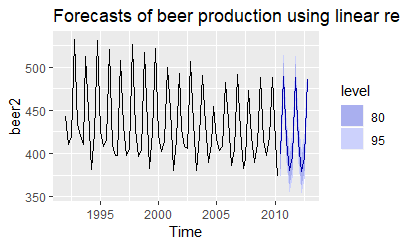

### Scenario based forecasting

In this setting, the forecaster assumes possible scenarios for the predictor variables that are of interest. For example, a US policy maker may be interested in comparing the predicted change in consumption when there is a constant growth of 1% and 0.5% respectively for income and savings with no change in the employment rate, versus a respective decline of 1% and 0.5%, for each of the four quarters following the end of the sample. The resulting forecasts are calculated below and shown in Figure @ref(fig:ConsInc4). We should note that prediction intervals for scenario based forecasts do not include the uncertainty associated with the future values of the predictor variables. They assume that the values of the predictors are known in advance.

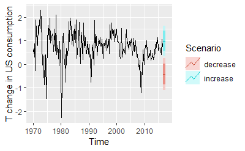

```r
fit.consBest <- tslm(Consumption ~ Income + Savings + Unemployment, data = uschange)
h <- 4
newdata <-
  cbind(Income=c(1,1,1,1), Savings=c(0.5,0.5,0.5,0.5), Unemployment=c(0,0,0,0)) %>%
  as.data.frame()
fcast.up <- forecast(fit.consBest, newdata=newdata)
newdata <-
  cbind(Income=rep(-1,h), Savings=rep(-0.5,h), Unemployment=rep(0,h)) %>%
  as.data.frame()
fcast.down <- forecast(fit.consBest, newdata=newdata)
autoplot(uschange[,1])+ylab("T change in US consumption")+
  forecast::autolayer(fcast.up, PI=TRUE,series="increase")+
  autolayer(fcast.down,PI=TRUE,series="decrease")+
  guides(colour=guide_legend(title="Scenario"))
```

### 2.7.2 Builing a predictive regression model

The great advantage of regression models is that they can be used to capture important relationships between the forecast variable of interest and the predictor variables. A major challenge however, is that in order to generate ex-ante forecasts the model requires future values of each predictor. If scenario based forecasting is of interest then these models are extremely useful. However, if ex-ante forecasting is the main focus, obtaining forecasts of the predictors can be very challenging (in many cases generating forecasts for the predictor variables can be more challenging than forecasting directly the forecast variable without using predictors).

An alternative formulation is to use as predictors their lagged values. Assuming that we are interested in generating a $h$-step ahead forecast we write
$$y_{t+h}=\beta_0+\beta_1x_{1,t}+\dots+\beta_kx_{k,t}+\varepsilon_{t+h}$$
for $h=1,2\ldots$. The predictor set is formed by values of the $x$s that are observed $h$ time periods prior to observing $y$. Therefore when the estimated model is projected into the future, i.e., beyond the end of the sample $T$, all predictor values are available.

Including lagged values of the predictors does not only make the model operational for easily generating forecasts, it also makes it intuitively appealling. For example, the effect of a policy change with the aim of increasing production may not have an instantaneous effect on consumption expenditure. It is most likely that this will happend with a lagging effect. We touched upon this in Section @ref(Regr-UsefulPredictors) when briefly introducing distributed lags as predictors. Several directions for generalising regression models to better incorporate the rich dynamics observed in time series are discussed In Section @ref(ch-dynamic).

### 2.7.3 Prediction intervals

With each forecast for the change in consumption Figure @ref(fig:ConsInc4) 95% and 80% prediction intervals are also included. The general formulation of how to calculate prediction intervals for multiple regression models is presented in Section @ref(Regr-MatrixEquations). As this involves some advanced matrix algebra we present here the case for calculating prediction intervals for a simple regression, where a forecast can be generated using the equation,

$$\hat{y}=\hat{\beta}_0+\hat{\beta}_1x.$$

Assuming that the regression errors are normally distributed, an approximate 95% prediction interval (also called a prediction interval) associated with this forecast is given by

$$\begin{equation}
\hat{y} \pm 1.96 \hat{\sigma}_e\sqrt{1+\frac{1}{T}+\frac{(x-\bar{x})^2}{(T-1)s_x^2}},
(\#eq:Regr-pi)
\end{equation}$$

where $T$ is the total number of observations, $\bar{x}$ is the mean of the observed $x$ values, $s_x$ is the standard deviation of the observed $x$ values and $\hat{\sigma}_e$ is the standard error of the regression given by Equation @ref(eq:Regr-se). Similarly, an 80% prediction interval can be obtained by replacing 1.96 by 1.28. Other prediction intervals can be obtained by replacing the 1.96 with the appropriate value given in Table @ref(tab:pcmultipliers). If R is used to obtain prediction intervals, more exact calculations are obtained (especially for small values of $T$) than what is given by Equation @ref(eq:Regr-pi).

Equation @ref(eq:Regr-pi) shows that the prediction interval is wider when $x$ is far from $\bar{x}$. That is, we are more certain about our forecasts when considering values of the predictor variable close to its sample mean.

#### 2.7.3.1 Example

The estimated simple regression line in the US consumption example is
$$\hat{y}_t=0.55 + 0.28x_t.$$

Assuming that for the next four quarters personal income will increase by its historical mean value of $\bar{x}=0.72\%$, consumption is forecast to increase by $0.75\%$ and the corresponding $95\%$ and $80\%$ prediction intervals are $[-0.45,1.94]$ and $[-0.03,1.52]$ respectively (calcualted using R). If we assume an extreme increase of $10\%$ in income then the prediction intervals are considerably wider as shown in Figure @ref(fig:conSimplePI).

[figure not shown]

```r
autoplot(uschange[,"Consumption"]) +
  ylab("% change in US consumption") +
  forecast::autolayer(fcast.up, PI=TRUE, series="Average increase") +
  forecast::autolayer(fcast.down, PI=TRUE, series="Extreme increase") +
  guides(colour=guide_legend(title="Scenario"))
```

## 2.8 Matrix formulation

*Warning: this is a more advanced optional section and assumes knowledge of matrix algebra.*

Recall that multiple regression model can be written as
$$y_{t} = \beta_{0} + \beta_{1}
x_{1,t} + \beta_{2} x_{2,t} + \cdots + \beta_{k} x_{k,t} + \varepsilon_{t}$$
where $\varepsilon_{t}$ has mean zero and variance $\sigma^2$. This expresses the relationship between a single value of the forecast variable and the predictors.

It can be convenient to write this in matrix form where all the values of the forecast variable are given in a single equation. Let $\bm{y} = (y_{1},\dots,y_{T})'$, $\bm{\varepsilon} = (\varepsilon_{1},\dots,\varepsilon_{T})'$, $\bm{\beta} = (\beta_{0},\dots,\beta_{k})'$ and
$$\bm{X} = \left[\begin{matrix}
1 & x_{1,1} & x_{2,1} & \dots & x_{k,1}\\
1 & x_{1,2} & x_{2,2} & \dots & x_{k,2}\\
\vdots& \vdots& \vdots&& \vdots\\
1 & x_{1,T}& x_{2,T}& \dots& x_{k,T}
\end{matrix}\right].$$
Then
$$\bm{y} = \bm{X}\bm{\beta} + \bm{\varepsilon}.$$

where $\bm{\varepsilon}$ has mean $\bm{0}$ and variance $\sigma^2\bm{I}$. Note that the $\bm{X}$ matrix has $T$ rows reflecting the number of observations and $k+1$ columns reflecting the intercept which is represented by the column of ones plus the number of predictors.

## 2.9 Least squares estimation

Least squares estimation is obtained by minimizing the expression $\bm{\varepsilon}'\bm{\varepsilon} = (\bm{y} - \bm{X}\bm{\beta})'(\bm{y} - \bm{X}\bm{\beta})$. It can be shown that this is minimized when $\bm{\beta}$ takes the value
$$\hat{\bm{\beta}} = (\bm{X}'\bm{X})^{-1}\bm{X}'\bm{y}$$
This is sometimes known as the “normal equation”. The estimated coefficients require the inversion of the matrix $\bm{X}'\bm{X}$. If $\bm{X}$ is not of full column rank then matrix $\bm{X}'\bm{X}$ is singular and the model cannot be estimated. This will occur, for example, if you fall for the “dummy variable trap”, i.e., having the same number of dummy variables as there are categories of a categorical predictor, as discussed in Section @ref(Regr-UsefulPredictors).

The residual variance is estimated using
$$\hat{\sigma}_e^2 =
\frac{1}{T-k-1}(\bm{y} - \bm{X}\hat{\bm{\beta}})'(\bm{y} -
\bm{X}\hat{\bm{\beta}}).$$

### Fitted values and cross-validation

The normal equation shows that the fitted values can be calculated using
$$\bm{\hat{y}} = \bm{X}\hat{\bm{\beta}} =
\bm{X}(\bm{X}'\bm{X})^{-1}\bm{X}'\bm{y} = \bm{H}\bm{y},$$
where $\bm{H} = \bm{X}(\bm{X}'\bm{X})^{-1}\bm{X}'$ is known as the “hat-matrix” because it is used to compute $\bm{\hat{y}}$ (“y-hat”).

If the diagonal values of $\bm{H}$ are denoted by $h_{1},\dots,h_{T}$, then the cross-validation statistic can be computed using
$$\text{CV} =
\frac{1}{T}\sum_{t=1}^T [e_{t}/(1-h_{t})]^2,$$
where $e_{t}$ is the residual obtained from fitting the model to all $T$ observations. Thus, it is not necessary to actually fit $T$ separate models when computing the CV statistic.

### Forecasts and prediction intervals

Let $\bm{x}^*$ be a row vector containing the values of the predictors (in the same format as $\bm{X}$) for which we want to generate a forecast . Then the forecast is given by
$$\hat{y} = \bm{x}^*\hat{\bm{\beta}}=\bm{x}^*(\bm{X}'\bm{X})^{-1}\bm{X}'\bm{Y}$$
and its variance is given by
$$\sigma^2 \left[1 + \bm{x}^* (\bm{X}'\bm{X})^{-1} (\bm{x}^*)'\right].$$
A 95% prediction interval can be calculated (assuming normally distributed errors) as
$$\hat{y} \pm 1.96 \hat{\sigma}_e \sqrt{1 + \bm{x}^* (\bm{X}'\bm{X})^{-1} (\bm{x}^*)'}.$$
This takes account of the uncertainty due to the error term $\varepsilon$ and the uncertainty in the coefficient estimates. However, it ignores any errors in $\bm{x}^*$. So if the future values of the predictors are uncertain, then the prediction interval calculated using this expression will be too narrow.

## 2.10 Nonlinear regression

Although the linear relationship assumed so far in this chapter is often adequate, there are many cases for which a nonlinear functional form is more suitable. To keep things simple in this section we assume that we only have one predictor $x$.

Simply transforming the forecast variable $y$ and/or the predictor variable $x$ and then estimating a regression model using the transformed variables is the simplest way of obtaining a nonlinear specification. We should note that these specifications and the specification that follow are still linear in the parameters. The most commonly used transformation is the (natural) logarithmic (see Section @ref(sec-transformations)).

A **log-log** functional form is specified as
$$\log y=\beta_0+\beta_1 \log x +\varepsilon.$$
In this model, the slope $\beta_1$ is interpreted as an elasticity, $\beta_1$ is the average percentage change in $y$ resulting from a $1\%$ increase in $x$. Other useful forms can also be specified. The **log-linear** form is specified by only transforming the forecast variable and the **linear-log** form is obtained by transforming the predictor.

Recall that in order to perform a logarithmic transformation to a variable, all its observed values must be greater than zero. In the case that variable $x$ contains zeros we use the transformation $\log(x+1)$, i.e., we add one to the value of the variable and then take logarithms. This has a similar effect to taking logarithms but avoids the problem of zeros. It also has the neat side-effect of zeros on the original scale remaining zeros on the transformed scale.

There are cases for which simply transforming the data will not be adequate and a more general specification may be required. Then the model we use is
$$y=f(x) +\varepsilon$$
where $f$ is a nonlinear function. In standard (linear) regression, $f(x)=\beta_{0} + \beta_{1} x$. In the specification of nonlinear regression that follows, we allow $f$ to be a more flexible nonlinear function of $x$, compared to simply a logarithmic or other transformation.

One of the simplest specifications is to make $f$ **piecewise linear**. That is, we introduce points where the slope of $f$ can change. These points are called “knots”. This can be achieved by letting $x_{1,t}=x$ and introducing variable $x_{2,t}$ such that

$$\begin{align*}
x_{2,t} = (x-c)_+ &= \left\{
\begin{array}{ll}
0 & x < c\\
(x-c) & x \ge c
\end{array}\right.
\end{align*}$$

The notation $(x-c)_+$ means the value $x-c$, if it is positive and 0 otherwise. This forces the slope to bend at point $c$. Additional bends can be included in the relationship by adding further variables of the above form.

An example of this follows by considering $x=t$ and fitting a piecewise linear trend to a times series.

Piecewise linear relationships constructed in this way are a special case of **regression splines**. In general, a linear regression spline is obtained using
$$x_{1}= x \quad x_{2} = (x-c_{1})_+ \quad\dots\quad x_{k} = (x-c_{k-1})_+$$
where $c_{1},\dots,c_{k-1}$ are the knots (the points at which the line can bend). Selecting the number of knots ($k-1$) and where they should be positioned can be difficult and somewhat arbitrary. Some automatic knot selection algorithms are available in some software, but are not yet widely used.

A smoother result is obtained using piecewise cubics rather than piecewise lines. These are constrained so they are continuous (they join up) and they are smooth (so there are no sudden changes of direction as we see with piecewise linear splines). In general, a cubic regression spline is written as
$$x_{1}= x \quad x_{2}=x^2 \quad x_3=x^3 \quad x_4 = (x-c_{1})_+ \quad\dots\quad x_{k} = (x-c_{k-3})_+.$$
Cubic splines usually give a better fit to the data. However, forecasting values of $y$ when $x$ is outside the range of the historical data becomes very unreliable.

### 2.10.1 Forecasting with nonlinear trend

In Section @ref(Regr-UsefulPredictors) fitting a linear trend to a time series by setting $x=t$ was introduced. The simplest way of fitting a nonlinear trend is using quadratic or higher order trends obtained by specifying
$$x_{1,t} =t,\quad x_{2,t}=t^2,\quad \ldots.$$
However, it is not recommended that quadratic or higher order trends are used in forecasting. When they are extrapolated, the resulting forecasts are often very unrealistic.

A better approach is to use the piecewise specification introduced above and fit a piecwise linear trend which bends at some point in time. We can think of this as a nonlinear trend constructed of linear pieces. If the trend bends at time $\tau$, then it can be specified by simply replacing $x=t$ and $c=\tau$ above such that we include the predictors,
$$\begin{align*}
x_{1,t} & = t \\
x_{2,t} = (t-\tau)_+ &= \left\{
\begin{array}{ll}
0 & t < \tau\\
(t-\tau) & t \ge \tau
\end{array}\right.
\end{align*}$$

in the model. If the associated coefficients of $x_{1,t}$ and $x_{2,t}$ are $\beta_1$ and $\beta_2$, then $\beta_1$ gives the slope of the trend before time $\tau$, while the slope of the line after time $\tau$ is given by $\beta_1+\beta_2$. Additional bends can be included in the relationship by adding further variables of the form $(t-\tau)_+$ where $\tau$ is the “knot” or point in time at which the line should bend.

#### 2.10.1.1 Example: Boston marathon winning times

[output not shown]

Fitting an exponential trend (equivalent to a log-linear regression) to the data can be achieved by transforming the $y$ variable so that the model to be fitted is,
$$log \ y_t = \beta_0 + \beta_1t + \epsilon_t,$$

This also addresses the **heteroskedasticity**. Thei fitted exponential trend and forecasts are shown in Fugre 5.21. Although the exponential trend does not seem to fit the data much better than the linear trend, it gives a more sensible projection in that the winning times will decrease in the future but at a decaying rate rather than a fixed linear rate.

The plot of winning times reveals three different periods. There is a lot of volatility in the winning times up to about 1940, with the winning times decreasing overall but with significant increases during the 1920s. After 1940 there is a near-linear decrease in times, followed by a flattening out after the 1980s, with the suggestion of an upturn towards the end of the sample. To account for these changes, we specify the years 1940 and 1980 as knots. We should warn here that subjective identification of knots can lead to over-fitting, which can be detrimental to the forecast performance of a model, and should be performed with caution.

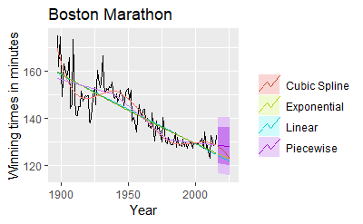

```r
h <- 10
fit.lin <- tslm(marathon ~ trend)
fcasts.lin <- forecast(fit.lin, h = h)
fit.exp <- tslm(marathon ~ trend, lambda = 0)
fcasts.exp <- forecast(fit.exp, h = h)
t <- time(marathon)
t.break1 <- 1940
t.break2 <- 1980
tb1 <- ts(pmax(0, t - t.break1), start = 1897)
tb2 <- ts(pmax(0, t - t.break2), start = 1897)
fit.pw <- tslm(marathon ~ t + tb1 + tb2)
t.new <- t[length(t)] + seq(h)
tb1.new <- tb1[length(tb1)] + seq(h)
tb2.new <- tb2[length(tb2)] + seq(h)
newdata <- cbind(t=t.new, tb1=tb1.new, tb2=tb2.new) %>%
  as.data.frame()
fcasts.pw <- forecast(fit.pw, newdata = newdata)
fit.spline <- tslm(marathon ~ t + I(t^2) + I(t^3) +
  I(tb1^3) + I(tb2^3))
fcasts.spl <- forecast(fit.spline, newdata = newdata)
autoplot(marathon) +
  autolayer(fitted(fit.lin), series = "Linear") +
  autolayer(fitted(fit.exp), series = "Exponential") +
  autolayer(fitted(fit.pw), series = "Piecewise") +
  autolayer(fitted(fit.spline), series = "Cubic Spline") +
  autolayer(fcasts.pw, series="Piecewise") +
  autolayer(fcasts.lin, series="Linear", PI=FALSE) +
  autolayer(fcasts.exp, series="Exponential", PI=FALSE) +
  autolayer(fcasts.spl, series="Cubic Spline", PI=FALSE) +
  xlab("Year") + ylab("Winning times in minutes") +
  ggtitle("Boston Marathon") +
  guides(colour = guide_legend(title = " "))
```

```
    Breusch-Godfrey test for serial correlation of order up to 10

data:  Residuals from Linear regression model
LM test = 21.597, df = 10, p-value = 0.0173
```

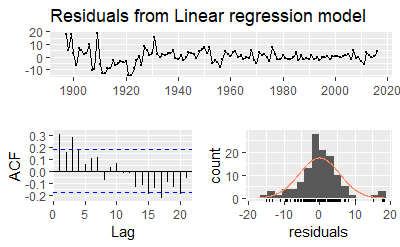

```r
checkresiduals(fit.pw)
```

There is an alternative formulation of cubic splines (called **natural cubic smoothing splines**) that imposes some constraints, so the spline function is linear at the end, which usually gives much better forecasts without compromising the fit. In Figure 5.22, we have used the `splinef()` function to produce the cubic spline forecasts. This uses many more knots than we used in Figure 5.21, but the coefficients are constrained to prevent over-fitting, and the curve is linear at both ends. This has the added advantage that knot selection is not subjective. We have also used a **log transformation** (`lambda=0`) to handle the **heteroscedasticity**.

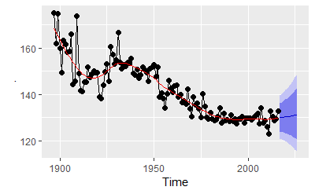

```r
marathon %>%
  splinef(lambda=0) %>%
  autoplot()
```

The residuals plotted in Figure 5.23 show that this model has captured the trend well, although there is some **heteroscedasticity** remaining. The wide prediction interval associated with the forecasts reflects the volatility observed in the historical winning times.

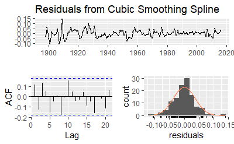

```r
marathon %>%
  splinef(lambda=0) %>%
  checkresiduals()
```

## 2.11 Correlation, causation and forecasting

### 2.11.1 Correlation is not causation

It is important not to confuse correlation with causation, or causation with forecasting. A variable $x$ may be useful for predicting a variable $y$, but that does not mean $x$ is causing $y$. It is possible that $x$ *is* causing $y$, but it may be that the relationship between them is more complicated than simple causality.

For example, it is possible to model the number of drownings at a beach resort each month with the number of ice-creams sold in the same period. The model can give reasonable forecasts, not because ice-creams cause drownings, but because people eat more ice-creams on hot days when they are also more likely to go swimming. So the two variables (ice-cream sales and drownings) are correlated, but one is not causing the other. It is important to understand that **correlations are useful for forecasting, even when there is no causal relationship between the two variables**.

However, often a better model is possible if a causal mechanism can be determined. In this example, both ice-cream sales and drownings will be affected by the temperature and by the numbers of people visiting the beach resort. Again, high temperatures do not actually *cause* people to drown, but they are more directly related to why people are swimming. So a better model for drownings will probably include temperatures and visitor numbers and exclude ice-cream sales.

### 2.11.2 Confounded predictors

A related issue involves confounding variables. Suppose we are forecasting monthly sales of a company for 2012, using data from 2000–2011. In January 2008 a new competitor came into the market and started taking some market share. At the same time, the economy began to decline. In your forecasting model, you include both competitor activity (measured using advertising time on a local television station) and the health of the economy (measured using GDP). It will not be possible to separate the effects of these two predictors because they are correlated. We say two variables are **confounded** when their effects on the forecast variable cannot be separated. Any pair of correlated predictors will have some level of confounding, but we would not normally describe them as confounded unless there was a relatively high level of correlation between them.

Confounding is not really a problem for forecasting, as we can still compute forecasts without needing to separate out the effects of the predictors. However, it becomes a problem with scenario forecasting as the scenarios should take account of the relationships between predictors. It is also a problem if some historical analysis of the contributions of various predictors is required.

### 2.11.3 Multicollnearity and forecasting

A closely related issue is **multicollinearity** which occurs when similar information is provided by two or more of the predictor variables in a multiple regression. It can occur in a number of ways.

Two predictors are highly correlated with each other (that is, they have a correlation coefficient close to +1 or -1). In this case, knowing the value of one of the variables tells you a lot about the value of the other variable. Hence, they are providing similar information.

A linear combination of predictors is highly correlated with another linear combination of predictors. In this case, knowing the value of the first group of predictors tells you a lot about the value of the second group of predictors. Hence, they are providing similar information.

The dummy variable trap is a special case of multicollinearity. Suppose you have quarterly data and use four dummy variables, $d_1,d_2,d_3$ and $d_4$. Then $d_4=1-d_1-d_2-d_3$, so there is perfect correlation between $d_4$ and $d_1+d_2+d_3$.

`TODO: I have changed this below - change back if not improved`

The dummy variable trap is a special case of multicollinearity, referred to as perfect multicollinearity. Suppose you have quarterly data and use four dummy variables, $d_1,~d_2,~d_3$ and $d_4$. Then $d_1+d_2+d_3+d_4=1$ and therefore there is perfect correlation between the column of ones representing the constant and the linear combination, in this case the sum, of the dummies.

In the case of **perfect correlation** (i.e., a correlation of +1 or -1, such as in the dummy variable trap), it is not possible to estimate the regression model. If there is **high correlation** (close to but not equal to +1 or -1), then the estimation of the regression coefficients is computationally difficult. In fact, some software (notably Microsoft Excel) may give highly **inaccurate estimates** of the coefficients. Most reputable statistical software will use algorithms to limit the effect of multicollinearity on the coefficient estimates, but you do need to be careful. The major software packages such as R, SPSS, SAS and Stata all use estimation algorithms to avoid the problem as much as possible.

The uncertainty associated with individual regression coefficients will be large. This is because they are difficult to estimate. Consequently, statistical tests (e.g., t-tests) on regression coefficients are unreliable. (In forecasting we are rarely interested in such tests.) Also, it will not be possible to make accurate statements about the contribution of each separate predictor to the forecast.

Forecasts will be unreliable if the values of the future predictors are outside the range of the historical values of the predictors. For example, suppose you have fitted a regression model with predictors $x_1$ and $x_2$ which are highly correlated with each other, and suppose that the values of $x_1$ in the fitting data ranged between 0 and 100. Then forecasts based on $x_1>100$ or $x_1<0$ will be unreliable. It is always a little dangerous when future values of the predictors lie much outside the historical range, but it is especially problematic when multicollinearity is present.

## 2.12 Exercise

1. Electricity consumption was recorded for a small town on 12 consecutive days. The following maximum temperatures (degrees Celsius) and consumption (megawatt-hours) were recorded for each day. `TODO: change the econsumption to a ts of 12 concecutive days - change the lm to tslm below`

|  | 1 | 2 | 3 | 4 | 5 | 6 | 7 | 8 | 9 | 10 | 11 | 12 |
| --- | --- | --- | --- | --- | --- | --- | --- | --- | --- | --- | --- | --- |
| Mwh | 16.3 | 16.8 | 15.5 | 18.2 | 15.2 | 17.5 | 19.8 | 19.0 | 17.5 | 16.0 | 19.6 | 18.0 |
| Temp | 29.3 | 21.7 | 23.7 | 10.4 | 29.7 | 11.9 | 9.0 | 23.4 | 17.8 | 30.0 | 8.6 | 11.8 |

1. Plot the data and find the regression model for Mwh with temperature as an explanatory variable. Why is there a negative relationship?
2. Produce a residual plot. Is the model adequate? Are there any outliers or influential observations?
3. Use the model to predict the electricity consumption that you would expect for the next day if the maximum temperature was $10^\circ$ and compare it with the forecast if the with maximum temperature was $35^\circ$. Do you believe these predictions?
4. Give prediction intervals for your forecasts. The following R code will get you started:

```r
plot(Mwh ~ temp, data=econsumption)
fit <- lm(Mwh ~ temp, data=econsumption)
plot(residuals(fit) ~ temp, data=econsumption)
forecast(fit, newdata=data.frame(temp=c(10,35)))
```

2. Data set `olympic` contains the winning times (in seconds) for the men’s 400 meters final in each Olympic Games from 1896 to 2012.
1. Plot the winning time against the year. Describe the main features of the scatterplot.
2. Fit a regression line to the data. Obviously the winning times have been decreasing, but at what *average* rate per year?
3. Plot the residuals against the year. What does this indicate about the suitability of the fitted line?
4. Predict the winning time for the men’s 400 meters final in the 2000, 2004, 2008 and 2012 Olympics. Give a prediction interval for each of your forecasts. What assumptions have you made in these calculations?
5. Find out the actual winning times for these Olympics (see www.databaseolympics.com). How good were your forecasts and prediction intervals?
3. Type `easter(ausbeer)` and interpret what you see.
4. An elasticity coefficient is the ratio of the percentage change in the forecast variable ($y$) to the percentage change in the predictor variable ($x$). Mathematically, the elasticity is defined as $(dy/dx)\times(x/y)$. Consider the log-log model,
   $$\log y=\beta_0+\beta_1 \log x + \varepsilon.$$
   Express $y$ as a function of $x$ and show that the coefficient $\beta_1$ is the elasticity coefficient.
5. The data set `fancy` concerns the monthly sales figures of a shop which opened in January 1987 and sells gifts, souvenirs, and novelties. The shop is situated on the wharf at a beach resort town in Queensland, Australia. The sales volume varies with the seasonal population of tourists. There is a large influx of visitors to the town at Christmas and for the local surfing festival, held every March since 1988. Over time, the shop has expanded its premises, range of products, and staff.
1. Produce a time plot of the data and describe the patterns in the graph. Identify any unusual or unexpected fluctuations in the time series.
2. Explain why it is necessary to take logarithms of these data before fitting a model.
3. Use R to fit a regression model to the logarithms of these sales data with a linear trend, seasonal dummies and a “surfing festival” dummy variable.
4. Plot the residuals against time and against the fitted values. Do these plots reveal any problems with the model?
5. Do boxplots of the residuals for each month. Does this reveal any problems with the model?
   6. What do the values of the coefficients tell you about each variable?
   7. What does the Breusch-Godfrey test tell you about your model?
   8. Regardless of your answers to the above questions, use your regression model to predict the monthly sales for 1994, 1995, and 1996. Produce prediction intervals for each of your forecasts.
   9. Transform your predictions and intervals to obtain predictions and intervals for the raw data.
   10. How could you improve these predictions by modifying the model?
5. `TODO: you got to this before me ;-)` The `gasoline` series consists of weekly data for supplies of US finished motor gasoline product, from 2 February 1991 to 20 January 2017. The units are in “thousand barrels per day”. Consider only the data to the end of 2004.
   1. Fit a harmonic regression with trend to the data. Select the appropriate number of Fourier terms to include by minimizing the AICc or CV value.
   2. Check the residuals of the final model using the `checkresiduals()` function. Even though the residuals fail the correlation tests, the results are probably not severe enough to make much difference to the forecasts and prediction intervals. (Note that the correlations are relatively small, even though they are significant.)
   3. To forecast using harmonic regression, you will need to generate the future values of the Fourier terms. This can be done as follows.

```r
fc <- forecast(fit, fourier(x, K, h))
```

where `fit` is the fitted model using `tslm`, `K` is the number of Fourier terms used in creating `fit`, and `h` is the forecast horizon required.

Forecast the next year of data.

4. Plot the forecasts along with the actual data for 2005. What do you find?
6. *(For advanced readers following on from Section @ref(Regr-MatrixEquations))*.

Using matrix notation it was shown that if $\bm{y}=\bm{X}\bm{\beta}+\bm{\varepsilon}$, where $\bm{e}$ has mean $\bm{0}$ and variance matrix $\sigma^2\bm{I}$, the estimated coefficients are given by $\hat{\bm{\beta}}=(\bm{X}'\bm{X})^{-1}\bm{X}'\bm{y}$ and a forecast is given by $\hat{y}=\bm{x}^*\hat{\bm{\beta}}=\bm{x}^*(\bm{X}'\bm{X})^{-1}\bm{X}'\bm{y}$ where $\bm{x}^*$ is a row vector containing the values of the regressors for the forecast (in the same format as $\bm{X}$), and the forecast variance is given by $var(\hat{y})=\sigma^2 \left[1+\bm{x}^*(\bm{X}'\bm{X})^{-1}(\bm{x}^*)'\right].$

Consider the simple time trend model where $y_t = \beta_0 + \beta_1t$. Using the following results,
$$\sum^{T}_{t=1}{t}=\frac{1}{2}T(T+1),\quad \sum^{T}_{t=1}{t^2}=\frac{1}{6}T(T+1)(2T+1)$$

derive the following expressions: a. $\displaystyle\bm{X}'\bm{X}=\frac{1}{6}\left[\begin{array}{cc}6T& 3T(T+1) \\3T(T+1) & T(T+1)(2T+1) \\\end{array}\right]$

2. $\displaystyle(\bm{X}'\bm{X})^{-1}=\frac{2}{T(T^2-1)}\left[\begin{array}{cc}(T+1)(2T+1) & -3(T+1) \\-3(T+1)& 6 \\\end{array}\right]$
3. $\displaystyle\hat{\beta}_0=\frac{2}{T(T-1)}\left[(2T+1)\sum^T_{t=1}y_t-3\sum^T_{t=1}ty_t\right]$

$\displaystyle\hat{\beta}_1=\frac{6}{T(T^2-1)}\left[2\sum^T_{t=1}ty_t-(T+1)\sum^T_{t=1}y_t \right]$

4. $\displaystyle\text{Var}(\hat{y}_{t})=\hat{\sigma}^2\left[1+\frac{2}{T(T-1)}\left(1-4T-6h+6\frac{(T+h)^2}{T+1}\right)\right]$

## 2.13 Further reading

Regression with time series data

- Shumway, R. H. and D. S. Stoffer (2011). Time series analysis and its applications: with R examples. 3rd ed. New York: Springer.

Note that if you are using good statistical software, if you are not interested in the specific contributions of each predictor, and if the future values of your predictor variables are within their historical ranges, there is nothing to worry about — multicollinearity is not a problem.

# 3 Time series decomposition

Time series data can exhibit a variety of patterns, and it is often helpful to split a time series into several components, each representing an underlying pattern category.

In Section 2.3 we discussed three types of time series patterns: trend, seasonality and cycles. When we decompose a time series into components, we usually combine the trend and cycle into a single trend-cycle component (sometimes called the trend for simplicity). Thus we think of a time series as comprising three components: a trend-cycle component, a seasonal component, and a remainder component (containing anything else in the time series).

In this chapter, we consider some common methods for extracting these components from a time series. Often this is done to help improve understanding of the time series, but it can also be used to improve forecast accuracy.

## 3.1 Time series components

**The additive model** is the most appropriate if the magnitude of the *seasonal fluctuations*, or the variation around the *trend-cycle*, does not vary with the level of the time series. When the variation in the seasonal pattern, or the variation around the trend-cycle, appears to be proportional to the level of the time series, then a multiplicative model is more appropriate. Multiplicative models are common with economic time series.

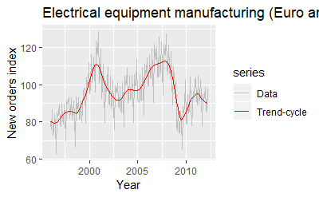

Figure @ref(fig:elecequip-trend) shows the **trend-cycle component**, $T_t$, in red and the original data, $y_t$, in grey. The trend-cycle shows the overall movement in the series, ignoring the seasonality and any small random fluctuations.

Figure @ref(fig:elecequip-stl) shows an additive decomposition of these data. The method used for estimating components in this example is STL, which is discussed in Section @ref(sec-6-stl).

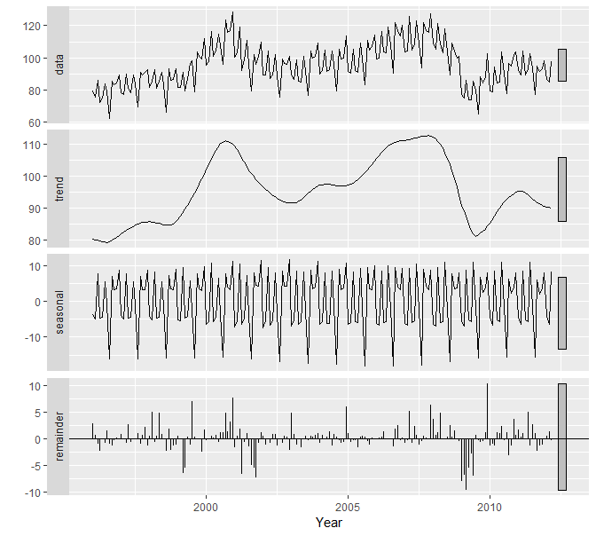

The three components are shown separately in the bottom three panels of Figure @ref(fig:elecequip-stl). These components can be added together to reconstruct the data shown in the top panel. Notice that the seasonal component changes very slowly over time, so that any two consecutive years have very similar patterns, but years far apart may have different seasonal patterns. The remainder component shown in the bottom panel is what is left over when the seasonal and trend-cycle components have been subtracted from the data.

The grey bars to the right of each panel show the relative scales of the components. Each grey bar represents the same length but because the plots are on different scales, the bars vary in size. The large grey bar in the bottom panel shows that the variation in the remainder component is small compared to the variation in the data, which has a bar about one quarter the size. If we shrunk the bottom three panels until their bars became the same size as that in the data panel, then all the panels would be on the same scale.

### 3.1.1 Seasonally adjusted data

If the seasonal component is removed from the original data, the resulting values are called the “seasonally adjusted” data. For an additive model, the seasonally adjusted data are given by $y_{t}-S_{t}$, and for multiplicative data, the seasonally adjusted values are obtained using $y_{t}/S_{t}$.

Figure @ref(fig:elecequip-sa) shows the seasonally adjusted electrical equipment orders.

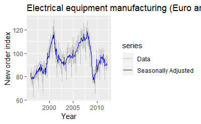

If the variation due to seasonality is not of primary interest, the **seasonally adjusted sereis** can be useful. For example, monthly unemployment data are usually seaonally adjusted in order to highlight variation due to the underlying state of the economy rather than the seasonal variation. An increase in unemployment due to school leavers seeking work is seasonal variation, while an increase in unemployment due to large employers laying off workers is non-seasonal. Most people who study unemployment data are more interested in the non-seasonal variation. Consequently, employment data (and many other economic series) are usually seasonally adjusted.

**Seasonally adjusted series** contain the remainder component as well as the trend-cycle. Therefore, they are not “smooth”, and “downturns” or “upturns” can be misleading. If the purpose is to look for turning points in the series, and interpret any changes in the series, then it is better to use the trend-cycle component rather than the seasonally adjusted data.

## 3.2 Moving averages

The classical method of time series decomposition originated in the 1920s and was widely used until the 1950s. IT still forms the basis of many time sereis decompsotion methods, si it is important to understand how it works. The first step in a classical decomposition is to use a moving average method to estimate the trend-cycle, so we begin by discussing moving averages.

### 3.2.1 Moving average smoothing

Moving average of order $m$ can be written as
$$\hat{T}_{t} = \frac{1}{m} \sum_{j=-k}^k y_{t+j},$$

,where $m=2k+1$. That is, the estimate of the trend-cycle at time $t$ is obtained by averaging values of the time series within $k$ periods of $t$. Observations that are nearby in time are also likely to be close in value, and the average eliminates some of the randomness in the data, leaving a smooth trend-cycle component. We call this an “$m$-MA”, meaning a moving average of order $m$.

```r
autoplot(elecsales)+xlab("Year")+ylab("GWh")+
  ggtitle("Annual electricity sales: South Australia")
```

[output not shown]

For example, consider Figure @ref(fig:ressales1) which shows the volume of electricity sold to residential customers in South Australia each year from 1989 to 2008 (hot water sales have been excluded). The data are also shown in Table @ref(tab:elecsales).

```
Ignoring unknown parameters: sereis
```

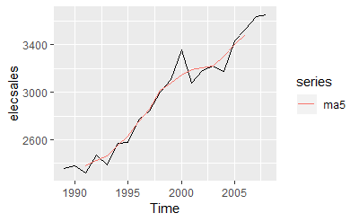

```r
# ts(as.data.frame(elecsales),frequency = 1, start=1989)
autoplot(elecsales)+
  autolayer(ma5, sereis="MA")
```

| Year | Sales (GWh) | 5-MA |
| --- | --- | --- |
| 1989 | 2354.34 |  |
| 1990 | 2379.71 |  |
| 1991 | 2318.52 | 2381.53 |
| 1992 | 2468.99 | 2424.56 |
| 1993 | 2386.09 | 2463.76 |
| 1994 | 2569.47 | 2552.60 |
| 1995 | 2575.72 | 2627.70 |
| 1996 | 2762.72 | 2750.62 |
| 1997 | 2844.50 | 2858.35 |
| 1998 | 3000.70 | 3014.70 |
| 1999 | 3108.10 | 3077.30 |
| 2000 | 3357.50 | 3144.52 |
| 2001 | 3075.70 | 3188.70 |
| 2002 | 3180.60 | 3202.32 |
| 2003 | 3221.60 | 3216.94 |
| 2004 | 3176.20 | 3307.30 |
| 2005 | 3430.60 | 3398.75 |
| 2006 | 3527.48 | 3485.43 |
| 2007 | 3637.89 |  |
| 2008 | 3655.00 |  |

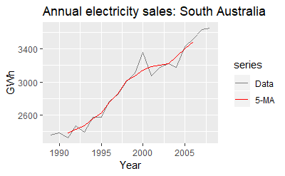

```r
autoplot(elecsales, series="Data")+
  forecast::autolayer(ma(elecsales,5),series="5-MA")+
  xlab("Year")+ylab("GWh")+
  ggtitle("Annual electricity sales: South Australia")+
  scale_colour_manual(values=c("Data"="grey50","5-MA"="red"),
                      breaks=c("Data","5-MA"))
```

Notice that the *trend-cycle* (in red) is smooother than the original data, and captures the main movement of the time series without all of the minor fluctuations. The moving average method does not allow estimates of $T_{t}$ when $t$ is close to the ends of the series; hence the red line does not extend to the edges of the graph on either side. Later we will use more sophisticated methods of trend-cycle estimation which do allow estimates near the endpoints.

The order of the moving average determines the smoothness of the trend-cycle estimate. In general, a larger order means a smoother curve. Figure @ref(fig:ressales3) shows the effect of changing the order of the moving average for the residential electricity sales data.

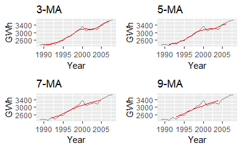

Simple moving averages such as these are usually of an odd order (e.g., 3, 5, 7, etc.) This is so they are symmetric: in a moving average of order $m=2k+1$, there are $k$ earlier observations, $k$ later observations and the middle observation that are averaged. But if $m$ was even, it would no longer be symmetric.

### 3.2.2 Moving averages of moving averages

It is possible to apply a moving average to a moving average. One reason for doing this is to make an even-order moving average symmetric.

For example, we might take a moving average of order 4, and then apply another moving average of order 2 to the results. In the following table, this has been done for the first few years of the Australian quarterly beer production data.

```r
beer2 <- window(ausbeer, start=1992)
ma4 <- ma(beer2, order=4, centre=FALSE)
ma2x4 <- ma(beer2, order=4, centre = TRUE)
```

| Year | Quarter | Observation | 4-MA | 2x4-MA |
| --- | --- | --- | --- | --- |
| 1992 | Q1 | 443 |  |  |
| 1992 | Q2 | 410 | 451.25 |  |
| 1992 | Q3 | 420 | 448.75 | 450.000 |
| 1992 | Q4 | 532 | 451.50 | 450.125 |
| 1993 | Q1 | 433 | 449.00 | 450.250 |
| 1993 | Q2 | 421 | 444.00 | 446.500 |
| 1993 | Q3 | 410 | 448.00 | 446.000 |
| 1993 | Q4 | 512 | 438.00 | 443.000 |
| 1994 | Q1 | 449 | 441.25 | 439.625 |
| 1994 | Q2 | 381 | 446.00 | 443.625 |
| 1994 | Q3 | 423 | 440.25 | 443.125 |
| 1994 | Q4 | 531 | 447.00 | 443.625 |
| 1995 | Q1 | 426 | 445.25 | 446.125 |
| 1995 | Q2 | 408 | 442.50 | 443.875 |
| 1995 | Q3 | 416 | 438.25 | 440.375 |
| 1995 | Q4 | 520 | 435.75 | 437.000 |
| 1996 | Q1 | 409 | 431.25 | 433.500 |
| 1996 | Q2 | 398 | 428.00 | 429.625 |
| 1996 | Q3 | 398 | 433.75 | 430.875 |
| 1996 | Q4 | 507 | 433.75 | 433.750 |

The notation “$2\times4$-MA” in the last column means a 4-MA followed by a 2-MA. The values in the last column are obtained by taking a moving average of order 2 of the values in the previous column. For example, the first two values in the 4-MA column are 451.25=(443+410+420+532)/4 and 448.75=(410+420+532+433)/4. The first value in the 2x4-MA column is the average of these two: 450.00=(451.25+448.75)/2.

When a 2-MA follows a moving average of an even order (such as 4), it is called a “centered moving average of order 4”. This is because the results are now symmetric. To see that this is the case, we can write the $2\times4$-MA as follows:
$$\begin{align*}
\hat{T}_{t} &= \frac{1}{2}\Big[
\frac{1}{4} (y_{t-2}+y_{t-1}+y_{t}+y_{t+1}) +
\frac{1}{4} (y_{t-1}+y_{t}+y_{t+1}+y_{t+2})\Big] \\
&= \frac{1}{8}y_{t-2}+\frac14y_{t-1} +
\frac14y_{t}+\frac14y_{t+1}+\frac18y_{t+2}.
\end{align*}$$

It is now a weighted average of observations, but it is symmetric.

Other combinations of moving averages are also possible. For example, a $3\times3$-MA is often used, and consists of a moving average of order 3 followed by another moving average of order 3. In general, an even order MA should be followed by an even order MA to make it symmetric. Similarly, an odd order MA should be followed by an odd order MA.

### 3.2.3 Estimating the trend-cycle with seasonal data

The most common use of centered moving averages is in estimating the **trend-cycle** from seasonal data. Consider the $2\times4$-MA:
$$\hat{T}_{t} = \frac{1}{8}y_{t-2} + \frac14y_{t-1} +
\frac14y_{t} + \frac14y_{t+1} + \frac18y_{t+2}.$$

When applied to quarterly data, each quarter of the year is given equal weight as the first and last terms apply to the same quarter in consecutive years. Consequently, the seasonal variation will be averaged out and the resulting values of $\hat{T}_t$ will have little or no seasonal variation remaining. A similar effect would be obtained using a $2\times 8$-MA or a $2\times 12$-MA to quarterly data.

In general, a $2\times m$-MA is equivalent to a weighted moving average of order $m+1$ where all observations take the weight $1/m$, except for the first and last terms which take weights $1/(2m)$. So, if the seasonal period is even and of order $m$, use a $2\times m$-MA to estimate the trend-cycle. If the seasonal period is odd and of order $m$, use a $m$-MA to estimate the trend-cycle. For example, a $2\times 12$-MA can be used to estimate the trend-cycle of monthly data and a 7-MA can be used to estimate the trend-cycle of daily data with a weekly seasonality.

Other choices for the order of the MA will usually result in trend-cycle estimates being contaminated by the seasonality in the data.

### Example: Electrical equipment manufacturing

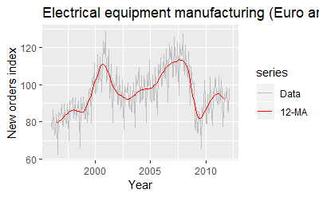

```r
autoplot(elecequip, series="Data")+
  forecast::autolayer(ma(elecequip,12),series="12-MA")+
  xlab("Year")+ylab("New orders index")+
  ggtitle("Electrical equipment manufacturing (Euro area)")+
  scale_color_manual(values=c("Data"="grey","12-MA"="red"),
                     breaks=c("Data","12-MA"))
```

Figure @ref(fig:elecequip2) shows a $2\times12$-MA applied to the electrical equipment orders index. Notice that the smooth line shows no seasonality; it is almost the same as the trend-cycle shown in Figure @ref(fig:elecequip-trend), which was estimated using a much more sophisticated method than moving averages. Any other choice for the order of the moving average (except for 24, 36, etc.) would have resulted in a smooth line that showed some seasonal fluctuations.

### 3.2.4 weighted moving averages

Combinations of moving averages result in weighted moving averages. For example, the $2\times4$-MA discussed above is equivalent to a weighted 5-MA with weights given by $\left[\frac{1}{8},\frac{1}{4},\frac{1}{4},\frac{1}{4},\frac{1}{8}\right]$. In general, a weighted $m$-MA can be written as
$$\hat{T}_t = \sum_{j=-k}^k a_j y_{t+j},$$
where $k=(m-1)/2$, and the weights are given by $\left[a_{-k},\dots,a_k\right]$. It is important that the weights all sum to one and that they are symmetric so that $a_j = a_{-j}$. The simple $m$-MA is a special case where all of the weights are equal to $1/m$.

A major advantage of weighted moving averages is that they yield a smoother estimate of the trend-cycle. Instead of observations entering and leaving the calculation at full weight, their weights slowly increase and then slowly decrease, resulting in a smoother curve.

Some specific sets of weights are widely used due to their mathematical properties. Some of these are given in Table @ref(tab:weights).

|  | *a*<sub>0</sub> | *a*<sub>1</sub> | *a*<sub>2</sub> | *a*<sub>3</sub> | *a*<sub>4</sub> | *a*<sub>5</sub> | *a*<sub>6</sub> | *a*<sub>7</sub> | *a*<sub>8</sub> | *a*<sub>9</sub> | *a*<sub>10</sub> | *a*<sub>11</sub> |
| --- | --- | --- | --- | --- | --- | --- | --- | --- | --- | --- | --- | --- |
| 3-MA | 0.333 | 0.333 |  |  |  |  |  |  |  |  |  |  |
| 5-MA | 0.200 | 0.200 | 0.200 |  |  |  |  |  |  |  |  |  |
| 2x12-MA | 0.083 | 0.083 | 0.083 | 0.083 | 0.083 | 0.083 | 0.042 |  |  |  |  |  |
| 3x3-MA | 0.333 | 0.222 | 0.111 |  |  |  |  |  |  |  |  |  |
| 3x5-MA | 0.200 | 0.200 | 0.133 | 0.067 |  |  |  |  |  |  |  |  |
| S15-MA | 0.231 | 0.209 | 0.144 | 0.066 | 0.009 | -0.016 | -0.019 | -0.009 |  |  |  |  |
| S21-MA | 0.171 | 0.163 | 0.134 | 0.094 | 0.051 | 0.017 | -0.006 | -0.014 | -0.014 | -0.009 | -0.003 |  |
| H5-MA | 0.558 | 0.294 | -0.073 |  |  |  |  |  |  |  |  |  |
| H9-MA | 0.330 | 0.267 | 0.119 | -0.010 | -0.041 |  |  |  |  |  |  |  |
| H13-MA | 0.240 | 0.214 | 0.147 | 0.066 | 0.000 | -0.028 | -0.019 |  |  |  |  |  |
| H23-MA | 0.148 | 0.138 | 0.122 | 0.097 | 0.068 | 0.039 | 0.013 | -0.005 | -0.015 | -0.016 | -0.011 | -0.004 |

## 3.3 Classical decomposition

The classical decomposition method originated in the 1920s. It is a relatively simple procedure, and forms the starting point for most other methods of time series decomposition. There are two forms of classical decomposition: an **additive decomposition** and a **multiplicative decomposition**. These are described below for a time series with seasonal period $m$ (e.g., $m=4$ for quarterly data, $m=12$ for monthly data, $m=7$ for daily data with a weekly pattern).

In classical decomposition, we assume that the seasonal component is constant from year to year. For multiplicative seasonality, the $m$ values that form the seasonal component are sometimes called the “seasonal indices”.

### 3.3.1 Additive decomposition

**Step 1**

If $m$ is an even number, compute the trend-cycle component using a $2\times m$-MA to obtain $\hat{T}_t$. If $m$ is an odd number, compute the trend-cycle component using an $m$-MA to obtain $\hat{T}_t$.

**Step 2**

Calculate the detrended series: $y_t - \hat{T}_t$.

**Step 3**

To estimate the seasonal component for each season, simply average the detrended values for that season. For example, with monthly data, the seasonal component for March is the average of all the detrended March values in the data. These seasonal component values are then adjusted to ensure that they add to zero. The seasonal component is obtained by stringing together these values for each year of data. This gives $\hat{S}_t$.

**Step 4**

The remainder component is calculated by subtracting the estimated seasonal and trend-cycle components: $\hat{R}_t = y_t - \hat{T}_t - \hat{S}_t$.

### 3.3.2 Multiplicative decomposition

A classical multiplicative decomposition is very similar, except that the subtractions are replaced by divisions.

**Step 1**

If $m$ is an even number, compute the trend-cycle component using a $2\times m$-MA to obtain $\hat{T}_t$. If $m$ is an odd number, compute the trend-cycle component using an $m$-MA to obtain $\hat{T}_t$.

**Step 2**

Calculate the detrended series: $y_t/ \hat{T}_t$.

**Step 3**

To estimate the seasonal component for each season, simply average the detrended values for that season. For example, with monthly data, the seasonal index for March is the average of all the detrended March values in the data. These seasonal indexes are then adjusted to ensure that they add to $m$. The seasonal component is obtained by stringing together all of the seasonal indices for each year of data. This gives $\hat{S}_t$.

**Step 4**

The remainder component is calculated by dividing out the estimated seasonal and trend-cycle components: $\hat{R}_{t} = y_t /( \hat{T}_t \hat{S}_t)$.

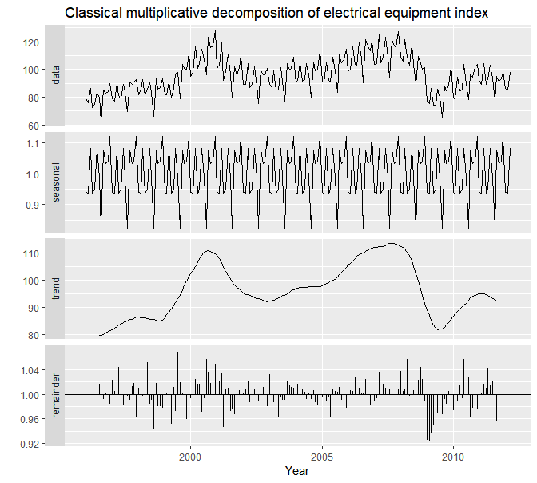

```r
elecequip %>%
  decompose(type="multiplicative") %>%
  autoplot()+xlab("Year")+
  ggtitle("Classical multiplicative decomposition of electrical equipment index")
```

Figure @ref(fig:classical-elecequip) shows a classical decomposition of the electrical equipment index. Compare this decomposition with that shown in Figure @ref(fig:elecequip-trend). The run of large negative remainder values in 2009 suggests that there is some “leakage” of the trend-cycle component into the remainder component. The trend-cycle estimate has over-smoothed the drop in the data, and the corresponding remainder values have been affected by the poor trend-cycle estimate.

### Comments on classical decomposition

While classical decomposition is still widely used, it is **not recommended**, as there are now several much better methods. Some of the problems with classical decomposition are summarised below.

- The estimate of the trend-cycle is unavailable for the first few and last few observations. For example, if $m=12$, there is no trend-cycle estimate for the first six or the last six observations. Consequently, there is also no estimate of the remainder component for the same time periods.
- The trend-cycle estimate tends to over-smooth rapid rises and falls in the data (as seen in the above example).
- Classical decomposition methods assume that the seasonal component repeats from year to year. For many series, this is a reasonable assumption, but for some longer series it is not. For example, electricity demand patterns have changed over time as air conditioning has become more widespread. Specifically, in many locations, the seasonal usage pattern from several decades ago had its maximum demand in winter (due to heating), while the current seasonal pattern has its maximum demand in summer (due to air conditioning). The classical decomposition methods are unable to capture these seasonal changes over time.
- Occasionally, the values of the time series in a small number of periods may be particularly unusual. For example, the monthly air passenger traffic may be affected by an industrial dispute, making the traffic during the dispute very different from usual. The classical method is not robust to these kinds of unusual values.